# R Notebook

Section 1 : DATA CLEANING

1)Take a summary of the data and explore the result. How many categorical and numerical variables are there in the dataset?

```r
house=read.csv("C:/Users/prabh/Downloads/dataset (1)/dataset/housing.csv")
```

```r
house=house[-1]
str(house)
```

```
'data.frame':   1460 obs. of  80 variables:
 $ MSSubClass   : int  60 20 60 70 60 50 20 60 50 190 ...
 $ MSZoning     : chr  "RL" "RL" "RL" "RL" ...
 $ LotFrontage  : int  65 80 68 60 84 85 75 NA 51 50 ...
 $ LotArea      : int  8450 9600 11250 9550 14260 14115 10084 10382 6120 7420 ...
 $ Street       : chr  "Pave" "Pave" "Pave" "Pave" ...
 $ Alley        : chr  NA NA NA NA ...
 $ LotShape     : chr  "Reg" "Reg" "IR1" "IR1" ...
 $ LandContour  : chr  "Lvl" "Lvl" "Lvl" "Lvl" ...
 $ Utilities    : chr  "AllPub" "AllPub" "AllPub" "AllPub" ...
 $ LotConfig    : chr  "Inside" "FR2" "Inside" "Corner" ...
 $ LandSlope    : chr  "Gtl" "Gtl" "Gtl" "Gtl" ...
 $ Neighborhood : chr  "CollgCr" "Veenker" "CollgCr" "Crawfor" ...
 $ Condition1   : chr  "Norm" "Feedr" "Norm" "Norm" ...
 $ Condition2   : chr  "Norm" "Norm" "Norm" "Norm" ...
```

[output cut: 66 more lines]

```r
summary(house)
```

```
   MSSubClass      MSZoning          LotFrontage        LotArea          Street
 Min.   : 20.0   Length:1460        Min.   : 21.00   Min.   :  1300   Length:1460
 1st Qu.: 20.0   Class :character   1st Qu.: 59.00   1st Qu.:  7554   Class :character
 Median : 50.0   Mode  :character   Median : 69.00   Median :  9478   Mode  :character
 Mean   : 56.9                      Mean   : 70.05   Mean   : 10517
 3rd Qu.: 70.0                      3rd Qu.: 80.00   3rd Qu.: 11602
 Max.   :190.0                      Max.   :313.00   Max.   :215245
                                    NA's   :259
    Alley             LotShape         LandContour         Utilities
 Length:1460        Length:1460        Length:1460        Length:1460
 Class :character   Class :character   Class :character   Class :character
 Mode  :character   Mode  :character   Mode  :character   Mode  :character




  LotConfig          LandSlope         Neighborhood        Condition1
 Length:1460        Length:1460        Length:1460        Length:1460
 Class :character   Class :character   Class :character   Class :character
 Mode  :character   Mode  :character   Mode  :character   Mode  :character




  Condition2          BldgType          HouseStyle         OverallQual
 Length:1460        Length:1460        Length:1460        Min.   : 1.000
 Class :character   Class :character   Class :character   1st Qu.: 5.000
 Mode  :character   Mode  :character   Mode  :character   Median : 6.000
                                                          Mean   : 6.099
                                                          3rd Qu.: 7.000
                                                          Max.   :10.000

  OverallCond      YearBuilt     YearRemodAdd   RoofStyle           RoofMatl
 Min.   :1.000   Min.   :1872   Min.   :1950   Length:1460        Length:1460
 1st Qu.:5.000   1st Qu.:1954   1st Qu.:1967   Class :character   Class :character
 Median :5.000   Median :1973   Median :1994   Mode  :character   Mode  :character
 Mean   :5.575   Mean   :1971   Mean   :1985
 3rd Qu.:6.000   3rd Qu.:2000   3rd Qu.:2004
 Max.   :9.000   Max.   :2010   Max.   :2010

```

[output cut: 96 more lines]

```
    MiscVal             MoSold           YrSold       SaleType         SaleCondition
 Min.   :    0.00   Min.   : 1.000   Min.   :2006   Length:1460        Length:1460
 1st Qu.:    0.00   1st Qu.: 5.000   1st Qu.:2007   Class :character   Class :character
 Median :    0.00   Median : 6.000   Median :2008   Mode  :character   Mode  :character
 Mean   :   43.49   Mean   : 6.322   Mean   :2008
 3rd Qu.:    0.00   3rd Qu.: 8.000   3rd Qu.:2009
 Max.   :15500.00   Max.   :12.000   Max.   :2010

   SalePrice
 Min.   : 34900
 1st Qu.:129975
 Median :163000
 Mean   :180921
 3rd Qu.:214000
 Max.   :755000
```

```r
sapply(colnames(house), function(x) class(house[[x]]))
```

```
   MSSubClass      MSZoning   LotFrontage       LotArea        Street         Alley
    "integer"   "character"     "integer"     "integer"   "character"   "character"
     LotShape   LandContour     Utilities     LotConfig     LandSlope  Neighborhood
  "character"   "character"   "character"   "character"   "character"   "character"
   Condition1    Condition2      BldgType    HouseStyle   OverallQual   OverallCond
  "character"   "character"   "character"   "character"     "integer"     "integer"
    YearBuilt  YearRemodAdd     RoofStyle      RoofMatl   Exterior1st   Exterior2nd
    "integer"     "integer"   "character"   "character"   "character"   "character"
   MasVnrType    MasVnrArea     ExterQual     ExterCond    Foundation      BsmtQual
  "character"     "integer"   "character"   "character"   "character"   "character"
     BsmtCond  BsmtExposure  BsmtFinType1    BsmtFinSF1  BsmtFinType2    BsmtFinSF2
  "character"   "character"   "character"     "integer"   "character"     "integer"
    BsmtUnfSF   TotalBsmtSF       Heating     HeatingQC    CentralAir    Electrical
    "integer"     "integer"   "character"   "character"   "character"   "character"
    X1stFlrSF     X2ndFlrSF  LowQualFinSF     GrLivArea  BsmtFullBath  BsmtHalfBath
    "integer"     "integer"     "integer"     "integer"     "integer"     "integer"
     FullBath      HalfBath  BedroomAbvGr  KitchenAbvGr   KitchenQual  TotRmsAbvGrd
    "integer"     "integer"     "integer"     "integer"   "character"     "integer"
   Functional    Fireplaces   FireplaceQu    GarageType   GarageYrBlt  GarageFinish
  "character"     "integer"   "character"   "character"     "integer"   "character"
   GarageCars    GarageArea    GarageQual    GarageCond    PavedDrive    WoodDeckSF
    "integer"     "integer"   "character"   "character"   "character"     "integer"
  OpenPorchSF EnclosedPorch    X3SsnPorch   ScreenPorch      PoolArea        PoolQC
    "integer"     "integer"     "integer"     "integer"     "integer"   "character"
        Fence   MiscFeature       MiscVal        MoSold        YrSold      SaleType
  "character"   "character"     "integer"     "integer"     "integer"   "character"
SaleCondition     SalePrice
  "character"     "integer"
```

ans: 43 categorical and 37 numerical variables are there in the dataset.

2)Which columns have missing values and what percentage of those columns have NAs? Is there any obvious outlier in the SalePrice? If so, remove them

```r
which(is.na(house))
```

[output not shown]

[output cut: 49 more lines]

```r
colSums(is.na(house))
```

```
   MSSubClass      MSZoning   LotFrontage       LotArea        Street         Alley
            0             0           259             0             0          1369
     LotShape   LandContour     Utilities     LotConfig     LandSlope  Neighborhood
            0             0             0             0             0             0
   Condition1    Condition2      BldgType    HouseStyle   OverallQual   OverallCond
            0             0             0             0             0             0
    YearBuilt  YearRemodAdd     RoofStyle      RoofMatl   Exterior1st   Exterior2nd
            0             0             0             0             0             0
   MasVnrType    MasVnrArea     ExterQual     ExterCond    Foundation      BsmtQual
            8             8             0             0             0            37
     BsmtCond  BsmtExposure  BsmtFinType1    BsmtFinSF1  BsmtFinType2    BsmtFinSF2
           37            38            37             0            38             0
    BsmtUnfSF   TotalBsmtSF       Heating     HeatingQC    CentralAir    Electrical
            0             0             0             0             0             1
    X1stFlrSF     X2ndFlrSF  LowQualFinSF     GrLivArea  BsmtFullBath  BsmtHalfBath
            0             0             0             0             0             0
     FullBath      HalfBath  BedroomAbvGr  KitchenAbvGr   KitchenQual  TotRmsAbvGrd
            0             0             0             0             0             0
   Functional    Fireplaces   FireplaceQu    GarageType   GarageYrBlt  GarageFinish
            0             0           690            81            81            81
   GarageCars    GarageArea    GarageQual    GarageCond    PavedDrive    WoodDeckSF
            0             0            81            81             0             0
  OpenPorchSF EnclosedPorch    X3SsnPorch   ScreenPorch      PoolArea        PoolQC
            0             0             0             0             0          1453
        Fence   MiscFeature       MiscVal        MoSold        YrSold      SaleType
         1179          1406             0             0             0             0
SaleCondition     SalePrice
            0             0
```

```r
length(which(is.na(house)))
```

```
[1] 6965
```

```r
iqr123 <-IQR(house$SalePrice)
iqr123
```

```
[1] 84025
```

```r
summary(house$SalePrice)
```

```
   Min. 1st Qu.  Median    Mean 3rd Qu.    Max.
  34900  129975  163000  180921  214000  755000
```

```r
left <- 129975-1.5*iqr123
right<- 214000+1.5*iqr123
left
```

```
[1] 3937.5
```

```r
right
```

```
[1] 340037.5
```

```r
x<-house$SalePrice
x[x<left | x>right]
```

```
 [1] 345000 385000 438780 383970 372402 412500 501837 475000 386250 403000 415298 360000
[13] 375000 342643 354000 377426 437154 394432 426000 555000 440000 380000 374000 430000
[25] 402861 446261 369900 451950 359100 345000 370878 350000 402000 423000 372500 392000
[37] 755000 361919 341000 538000 395000 485000 582933 385000 350000 611657 395192 348000
[49] 556581 424870 625000 392500 745000 367294 465000 378500 381000 410000 466500 377500
[61] 394617
```

```r
length(which(x<left | x>right))
```

```
[1] 61
```

For those variables for which NA means not applicable, you can replace NA with zero ( if that variable is numeric) or replace it with a new category/level, for instance, “notApplicable” if that variable is categorical.

```r
house[is.na(house$Alley), "Alley"]= "not applicable"
house[is.na(house$BsmtQual), "BsmtQual"]= "not applicable"
house[is.na(house$BsmtCond), "BsmtCond"]= "not applicable"
house[is.na(house$BsmtExposure), "BsmtExposure"]= "not applicable"
house[is.na(house$BsmtFinType1), "BsmtFinType1"]= "not applicable"
house[is.na(house$BsmtFinType2), "BsmtFinType2"]= "not applicable"
house[is.na(house$FireplaceQu), "FireplaceQu"]= "not applicable"
house[is.na(house$GarageType), "GarageType"]= "not applicable"
house[is.na(house$GarageCond), "GarageCond"]= "not applicable"
house[is.na(house$GarageFinish), "GarageFinish"]= "not applicable"
house[is.na(house$GarageQual), "GarageQual"]= "not applicable"
house[is.na(house$PoolQC), "PoolQC"]= "not applicable"
house[is.na(house$Fence), "Fence"]= "not applicable"
house[is.na(house$MiscFeature), "MiscFeature"]= "not applicable"
```

```r
house[is.na(house$GarageYrBlt), "GarageYrBlt"]= 0
```

4. After replacing not applicable NAs with appropriate values, find out which columns (if any) still have NAs and what percentage of each column is missing.

```r
colSums(is.na(house))
```

```
   MSSubClass      MSZoning   LotFrontage       LotArea        Street         Alley
            0             0           259             0             0             0
     LotShape   LandContour     Utilities     LotConfig     LandSlope  Neighborhood
            0             0             0             0             0             0
   Condition1    Condition2      BldgType    HouseStyle   OverallQual   OverallCond
            0             0             0             0             0             0
    YearBuilt  YearRemodAdd     RoofStyle      RoofMatl   Exterior1st   Exterior2nd
            0             0             0             0             0             0
   MasVnrType    MasVnrArea     ExterQual     ExterCond    Foundation      BsmtQual
            8             8             0             0             0             0
     BsmtCond  BsmtExposure  BsmtFinType1    BsmtFinSF1  BsmtFinType2    BsmtFinSF2
            0             0             0             0             0             0
    BsmtUnfSF   TotalBsmtSF       Heating     HeatingQC    CentralAir    Electrical
            0             0             0             0             0             1
    X1stFlrSF     X2ndFlrSF  LowQualFinSF     GrLivArea  BsmtFullBath  BsmtHalfBath
            0             0             0             0             0             0
     FullBath      HalfBath  BedroomAbvGr  KitchenAbvGr   KitchenQual  TotRmsAbvGrd
            0             0             0             0             0             0
   Functional    Fireplaces   FireplaceQu    GarageType   GarageYrBlt  GarageFinish
            0             0             0             0             0             0
   GarageCars    GarageArea    GarageQual    GarageCond    PavedDrive    WoodDeckSF
            0             0             0             0             0             0
  OpenPorchSF EnclosedPorch    X3SsnPorch   ScreenPorch      PoolArea        PoolQC
            0             0             0             0             0             0
        Fence   MiscFeature       MiscVal        MoSold        YrSold      SaleType
            0             0             0             0             0             0
SaleCondition     SalePrice
            0             0
```

```r
length(which(is.na(house)))
```

```
[1] 276
```

```r
(colMeans(is.na(house)))*100
```

```
   MSSubClass      MSZoning   LotFrontage       LotArea        Street         Alley
   0.00000000    0.00000000   17.73972603    0.00000000    0.00000000    0.00000000
     LotShape   LandContour     Utilities     LotConfig     LandSlope  Neighborhood
   0.00000000    0.00000000    0.00000000    0.00000000    0.00000000    0.00000000
   Condition1    Condition2      BldgType    HouseStyle   OverallQual   OverallCond
   0.00000000    0.00000000    0.00000000    0.00000000    0.00000000    0.00000000
    YearBuilt  YearRemodAdd     RoofStyle      RoofMatl   Exterior1st   Exterior2nd
   0.00000000    0.00000000    0.00000000    0.00000000    0.00000000    0.00000000
   MasVnrType    MasVnrArea     ExterQual     ExterCond    Foundation      BsmtQual
   0.54794521    0.54794521    0.00000000    0.00000000    0.00000000    0.00000000
     BsmtCond  BsmtExposure  BsmtFinType1    BsmtFinSF1  BsmtFinType2    BsmtFinSF2
   0.00000000    0.00000000    0.00000000    0.00000000    0.00000000    0.00000000
    BsmtUnfSF   TotalBsmtSF       Heating     HeatingQC    CentralAir    Electrical
   0.00000000    0.00000000    0.00000000    0.00000000    0.00000000    0.06849315
    X1stFlrSF     X2ndFlrSF  LowQualFinSF     GrLivArea  BsmtFullBath  BsmtHalfBath
   0.00000000    0.00000000    0.00000000    0.00000000    0.00000000    0.00000000
     FullBath      HalfBath  BedroomAbvGr  KitchenAbvGr   KitchenQual  TotRmsAbvGrd
   0.00000000    0.00000000    0.00000000    0.00000000    0.00000000    0.00000000
   Functional    Fireplaces   FireplaceQu    GarageType   GarageYrBlt  GarageFinish
   0.00000000    0.00000000    0.00000000    0.00000000    0.00000000    0.00000000
   GarageCars    GarageArea    GarageQual    GarageCond    PavedDrive    WoodDeckSF
   0.00000000    0.00000000    0.00000000    0.00000000    0.00000000    0.00000000
  OpenPorchSF EnclosedPorch    X3SsnPorch   ScreenPorch      PoolArea        PoolQC
   0.00000000    0.00000000    0.00000000    0.00000000    0.00000000    0.00000000
        Fence   MiscFeature       MiscVal        MoSold        YrSold      SaleType
   0.00000000    0.00000000    0.00000000    0.00000000    0.00000000    0.00000000
SaleCondition     SalePrice
   0.00000000    0.00000000
```

5)what percentage of rows in the dataset have one or more missing values?

```r
j1=complete.cases(house)
tab= table(j1)
prop.table(tab)
```

```
j1
    FALSE      TRUE
0.1821918 0.8178082
```

changing categorical into factor variables.

```r
library(dplyr)
house = house %>%
    mutate_if(is.character,as.factor)
str(house)
```

```
'data.frame':   1460 obs. of  80 variables:
 $ MSSubClass   : int  60 20 60 70 60 50 20 60 50 190 ...
 $ MSZoning     : Factor w/ 5 levels "C (all)","FV",..: 4 4 4 4 4 4 4 4 5 4 ...
 $ LotFrontage  : int  65 80 68 60 84 85 75 NA 51 50 ...
 $ LotArea      : int  8450 9600 11250 9550 14260 14115 10084 10382 6120 7420 ...
 $ Street       : Factor w/ 2 levels "Grvl","Pave": 2 2 2 2 2 2 2 2 2 2 ...
 $ Alley        : Factor w/ 3 levels "Grvl","not applicable",..: 2 2 2 2 2 2 2 2 2 2 ...
 $ LotShape     : Factor w/ 4 levels "IR1","IR2","IR3",..: 4 4 1 1 1 1 4 1 4 4 ...
 $ LandContour  : Factor w/ 4 levels "Bnk","HLS","Low",..: 4 4 4 4 4 4 4 4 4 4 ...
 $ Utilities    : Factor w/ 2 levels "AllPub","NoSeWa": 1 1 1 1 1 1 1 1 1 1 ...
 $ LotConfig    : Factor w/ 5 levels "Corner","CulDSac",..: 5 3 5 1 3 5 5 1 5 1 ...
 $ LandSlope    : Factor w/ 3 levels "Gtl","Mod","Sev": 1 1 1 1 1 1 1 1 1 1 ...
 $ Neighborhood : Factor w/ 25 levels "Blmngtn","Blueste",..: 6 25 6 7 14 12 21 17 18 4 ...
 $ Condition1   : Factor w/ 9 levels "Artery","Feedr",..: 3 2 3 3 3 3 3 5 1 1 ...
 $ Condition2   : Factor w/ 8 levels "Artery","Feedr",..: 3 3 3 3 3 3 3 3 3 1 ...
```

[output cut: 66 more lines]

section 2:Data Exploration

plot the histogram of SalePrice. Interpret the histogram. Is SalePrice variable skewed?

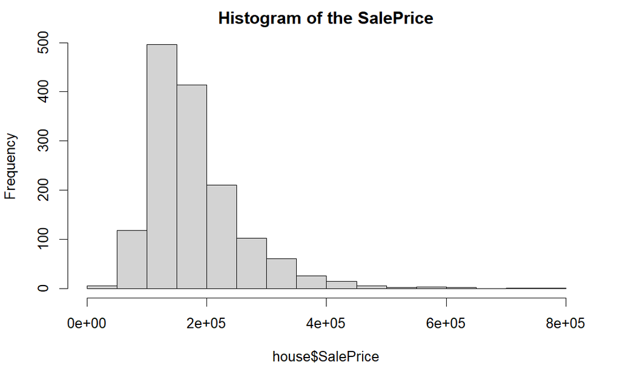

```r
hist(house$SalePrice, main = "Histogram of the SalePrice")
```

ans:Histogram of SalePrice variable is Right-skewed, the tallest bar is at the left hand side of the diagram.

draw scatter and side by side box plots of other variables against the Sale Price. From these plots, what variables seem to have correlation with SalePrice?

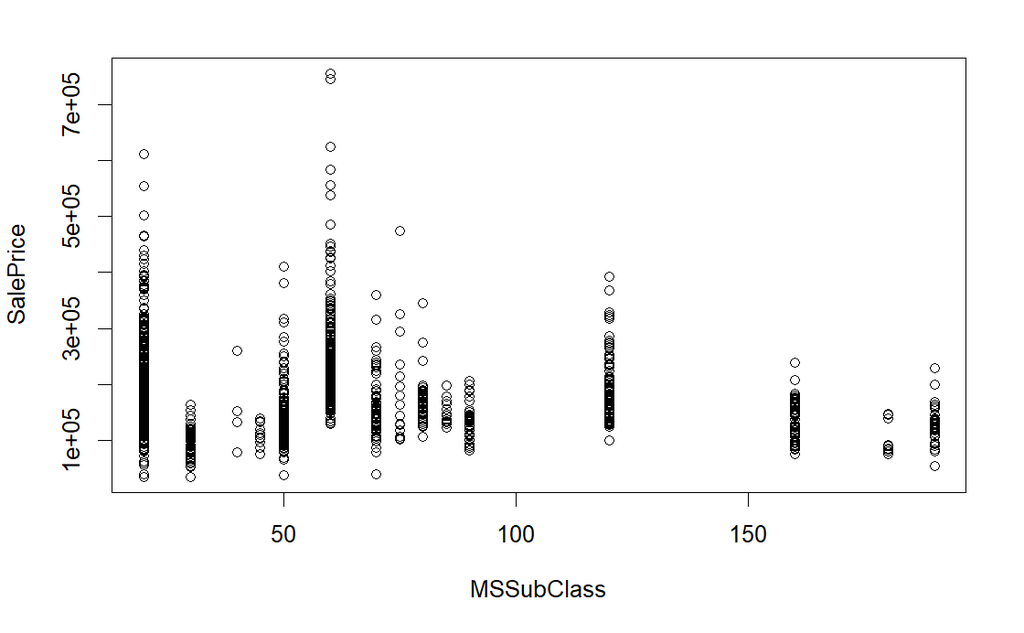

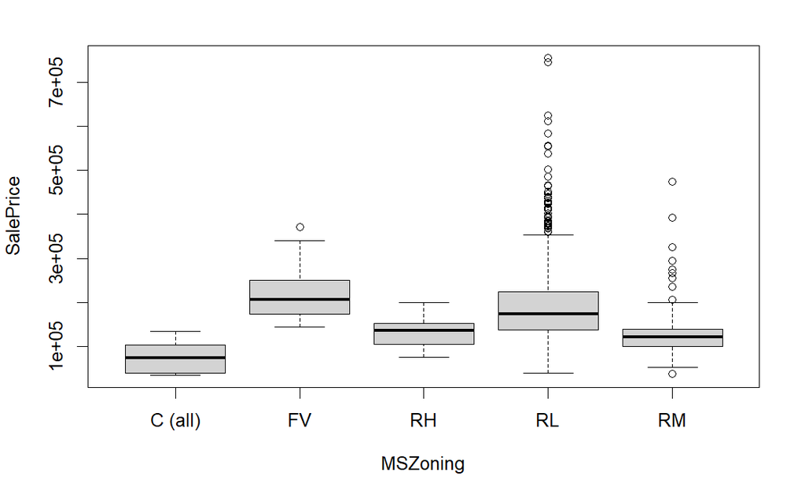

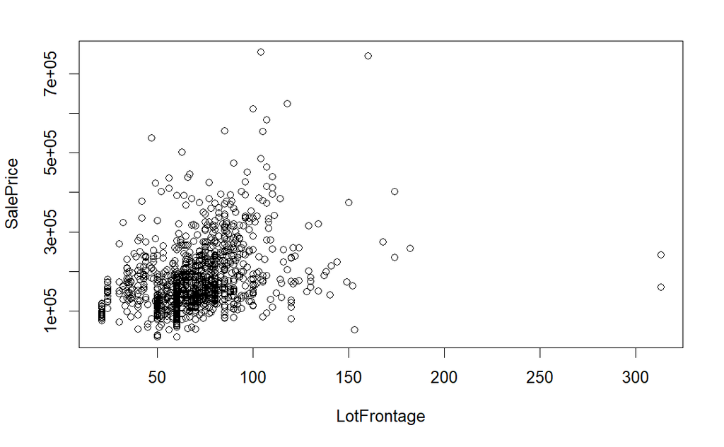

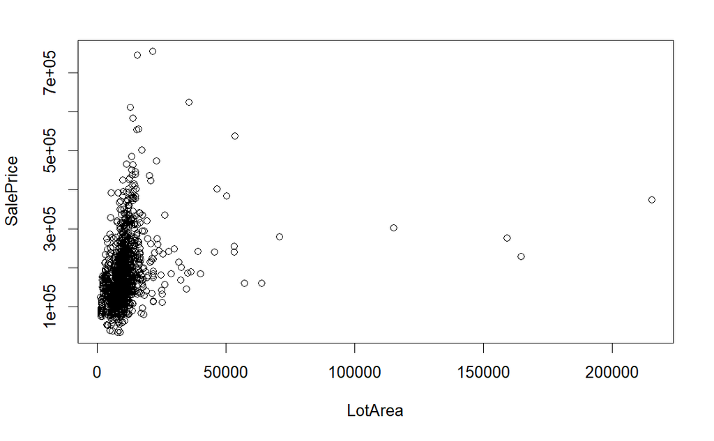

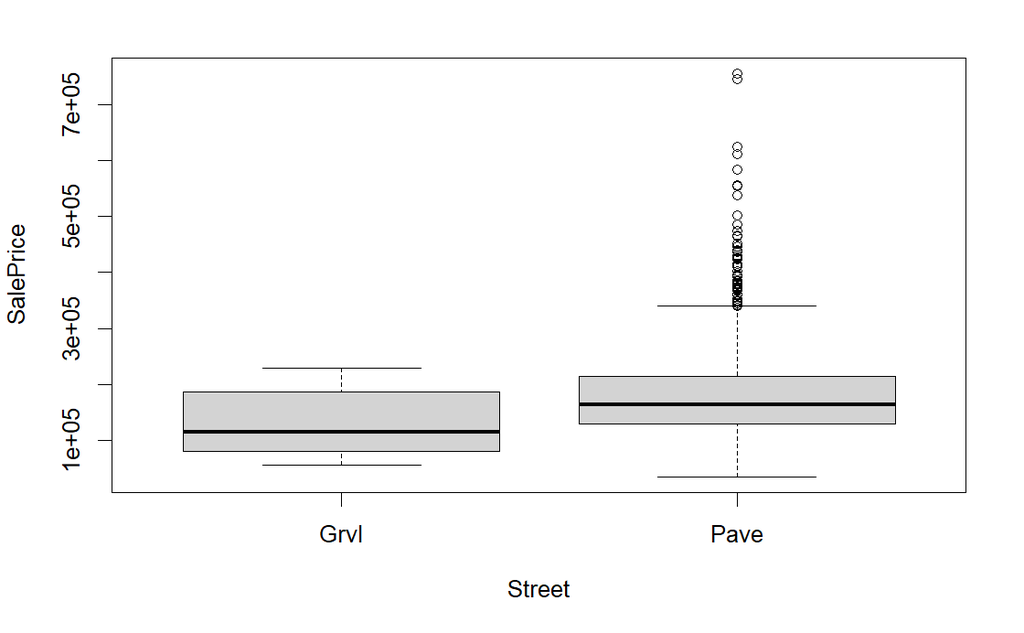

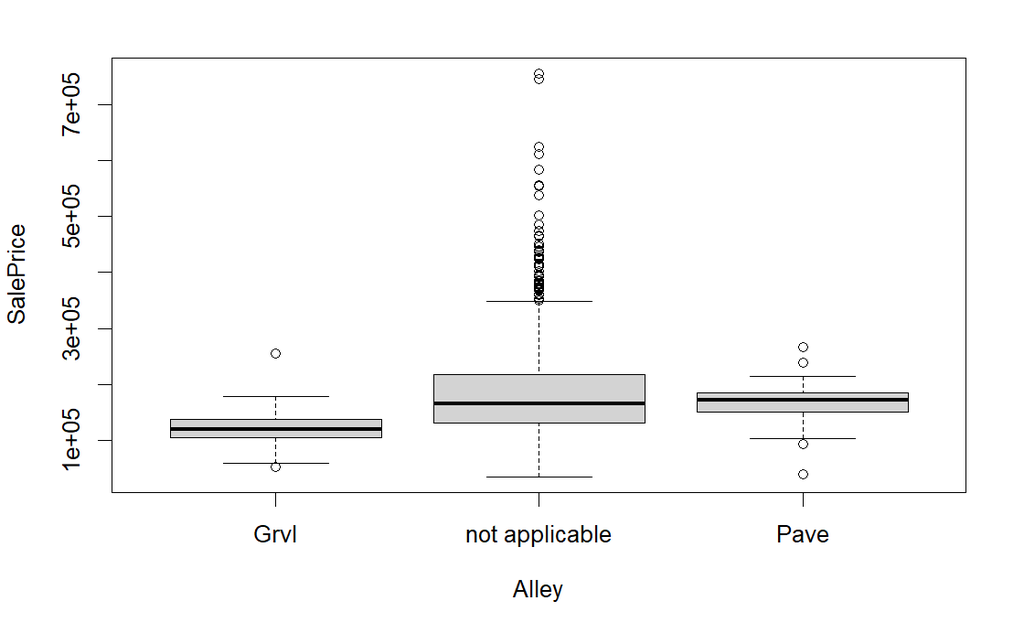

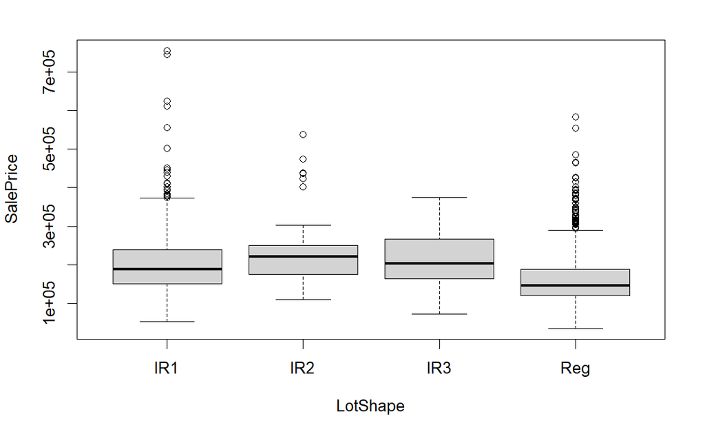

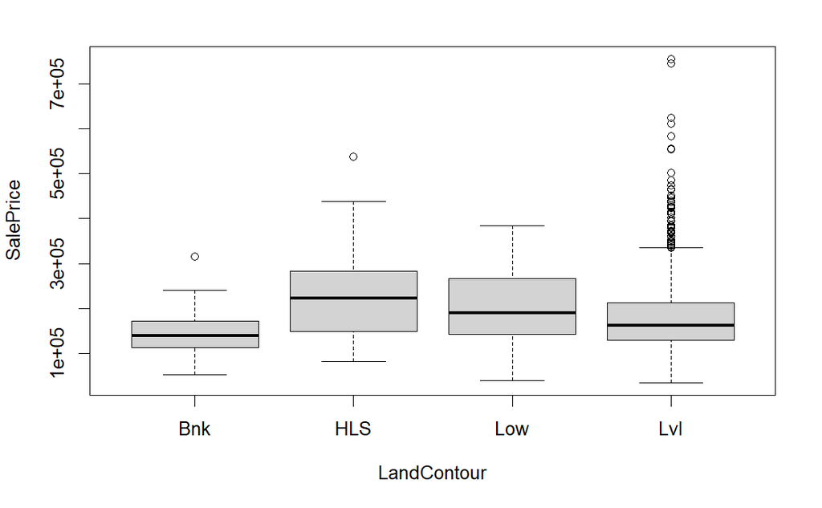

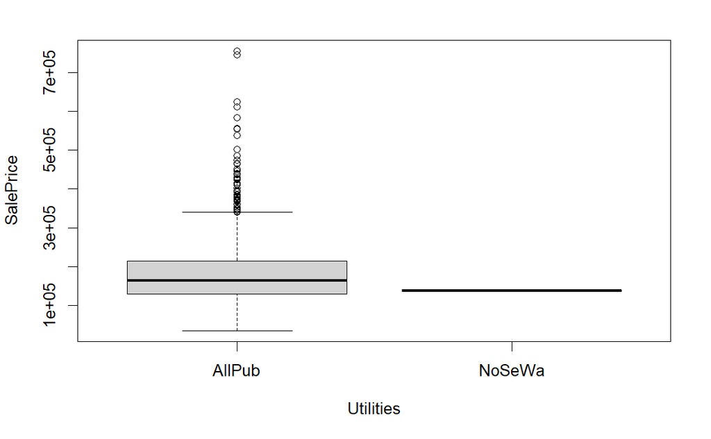

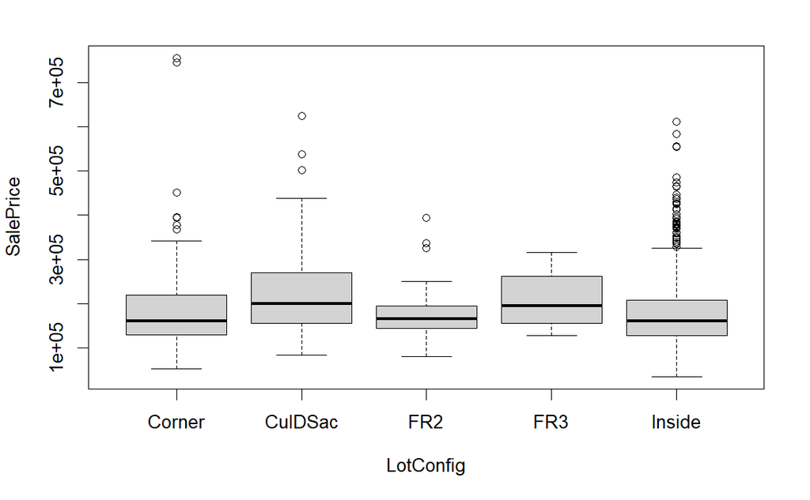

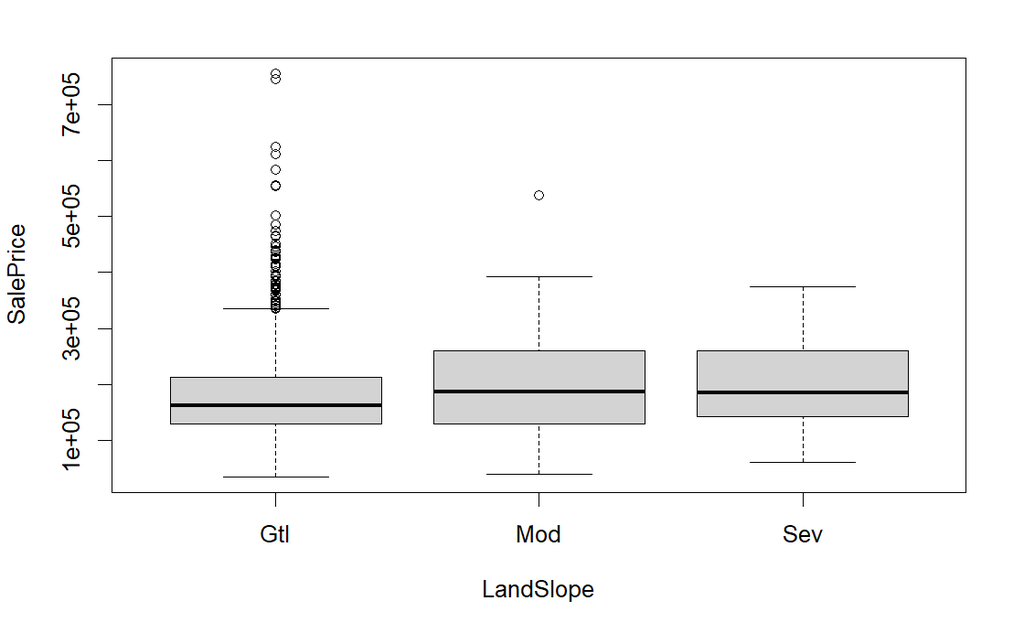

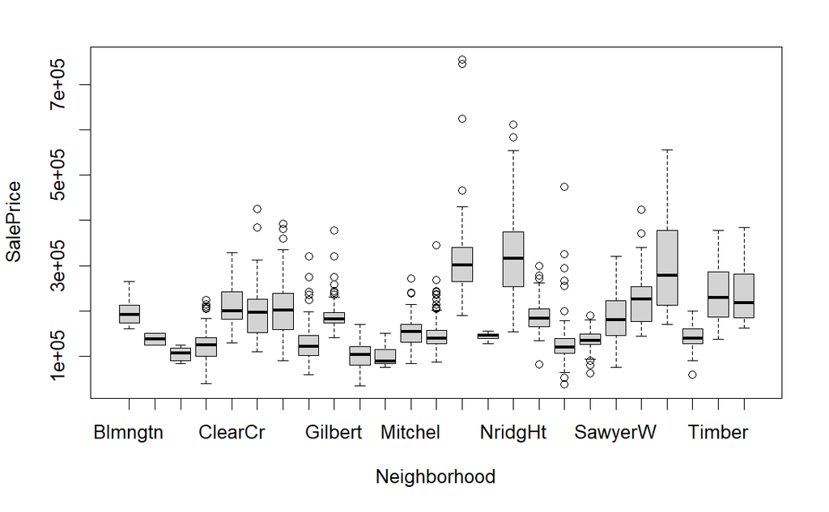

[67 more figures not shown]

```r
plot(SalePrice~.,data=house)
```

ans: correlation with SalePrice Moderate correlation - LotFrontage,YearBuilt,YearRemodAdd,MasVnrArea,BsmtFinSF1,X2ndFlrSF, FullBath,TotRmsAbvGrd,Fireplaces,WoodDeckSF,OpenPorchSF, Strong correlation - OverallQual,TotalBsmtSF,X1stFlrSF,GrLivArea,GarageCars,GarageArea,

Examine the columns with missing values to see if any of them are categorical. Use caret’s createDataPartition method to partition the dataset to 80% training and 20% testing. If a categorical column has missing values in train or test data, impute it with the mode of that column in the training data. It is important that the mode is computed based only on the training data only (instead of the entire dataset) to avoid data leakage.

```r
library(caret)
intrain= createDataPartition(house$SalePrice, p=0.8, list= FALSE)
house_train= house[intrain,]

house_test = house[-intrain,]
```

```r
replaceNA= function(x){

    t1 = table(x)
    mode = names(which(t1==max(t1)))
    x[is.na(x)]= mode

  return(x)
}
house_train$MasVnrType=replaceNA(house_train$MasVnrType)

house_train$Electrical=replaceNA(house_train$Electrical)

colSums(is.na(house_train))
```

```
   MSSubClass      MSZoning   LotFrontage       LotArea        Street         Alley
            0             0           214             0             0             0
     LotShape   LandContour     Utilities     LotConfig     LandSlope  Neighborhood
            0             0             0             0             0             0
   Condition1    Condition2      BldgType    HouseStyle   OverallQual   OverallCond
            0             0             0             0             0             0
    YearBuilt  YearRemodAdd     RoofStyle      RoofMatl   Exterior1st   Exterior2nd
            0             0             0             0             0             0
   MasVnrType    MasVnrArea     ExterQual     ExterCond    Foundation      BsmtQual
            0             3             0             0             0             0
     BsmtCond  BsmtExposure  BsmtFinType1    BsmtFinSF1  BsmtFinType2    BsmtFinSF2
            0             0             0             0             0             0
    BsmtUnfSF   TotalBsmtSF       Heating     HeatingQC    CentralAir    Electrical
            0             0             0             0             0             0
    X1stFlrSF     X2ndFlrSF  LowQualFinSF     GrLivArea  BsmtFullBath  BsmtHalfBath
            0             0             0             0             0             0
     FullBath      HalfBath  BedroomAbvGr  KitchenAbvGr   KitchenQual  TotRmsAbvGrd
            0             0             0             0             0             0
   Functional    Fireplaces   FireplaceQu    GarageType   GarageYrBlt  GarageFinish
            0             0             0             0             0             0
   GarageCars    GarageArea    GarageQual    GarageCond    PavedDrive    WoodDeckSF
            0             0             0             0             0             0
  OpenPorchSF EnclosedPorch    X3SsnPorch   ScreenPorch      PoolArea        PoolQC
            0             0             0             0             0             0
        Fence   MiscFeature       MiscVal        MoSold        YrSold      SaleType
            0             0             0             0             0             0
SaleCondition     SalePrice
            0             0
```

```r
mode= function(x){

    t1 = table(x)
    mode = names(which(t1==max(t1)))

  return(mode)
}
train_mode=mode(house_train$MasVnrType)

house_test$MasVnrType[is.na(house_test$MasVnrType)]= train_mode

train_mode1=mode(house_train$Electrical)
house_test$Electrical[is.na(house_test$Electrical)]= train_mode1

colSums(is.na(house_test))
```

```
   MSSubClass      MSZoning   LotFrontage       LotArea        Street         Alley
            0             0            45             0             0             0
     LotShape   LandContour     Utilities     LotConfig     LandSlope  Neighborhood
            0             0             0             0             0             0
   Condition1    Condition2      BldgType    HouseStyle   OverallQual   OverallCond
            0             0             0             0             0             0
    YearBuilt  YearRemodAdd     RoofStyle      RoofMatl   Exterior1st   Exterior2nd
            0             0             0             0             0             0
   MasVnrType    MasVnrArea     ExterQual     ExterCond    Foundation      BsmtQual
            0             5             0             0             0             0
     BsmtCond  BsmtExposure  BsmtFinType1    BsmtFinSF1  BsmtFinType2    BsmtFinSF2
            0             0             0             0             0             0
    BsmtUnfSF   TotalBsmtSF       Heating     HeatingQC    CentralAir    Electrical
            0             0             0             0             0             0
    X1stFlrSF     X2ndFlrSF  LowQualFinSF     GrLivArea  BsmtFullBath  BsmtHalfBath
            0             0             0             0             0             0
     FullBath      HalfBath  BedroomAbvGr  KitchenAbvGr   KitchenQual  TotRmsAbvGrd
            0             0             0             0             0             0
   Functional    Fireplaces   FireplaceQu    GarageType   GarageYrBlt  GarageFinish
            0             0             0             0             0             0
   GarageCars    GarageArea    GarageQual    GarageCond    PavedDrive    WoodDeckSF
            0             0             0             0             0             0
  OpenPorchSF EnclosedPorch    X3SsnPorch   ScreenPorch      PoolArea        PoolQC
            0             0             0             0             0             0
        Fence   MiscFeature       MiscVal        MoSold        YrSold      SaleType
            0             0             0             0             0             0
SaleCondition     SalePrice
            0             0
```

SECTION 3:Creating Regularized Linear Regression Models

Set.seed(1) and train a Lasso Linear Regression model using “glmnet” and “caret” as explained in the lectures to predict the SalePrice. Use 10 fold cross validation and Tune the lambda parameter)

```r
library(caret)
library(RANN)
set.seed(1)
lasso <-train(
SalePrice~., data = house_train, method = "glmnet",
trControl= trainControl("cv", number = 10), na.action=na.pass, preProc="knnImpute",
tuneGrid= expand.grid(alpha = 1, lambda = 10^seq(-3, 3, length = 100)))
```

ans: Lasso shrink some of the coefficients to zero, which means those variable is not used for prediction.

set.seed(1) again and train a Ridge linear regression model using 10 fold cross validation and tune lambda as you did for lasso and compute the RMSE of this model on the test data. Use knn imputation similar to what you did for lasso.

```r
set.seed(1)
ridge <-train(
SalePrice~., data = house_train, method = "glmnet",
trControl= trainControl("cv", number = 10),na.action=na.pass, preProc="knnImpute",
tuneGrid= expand.grid(alpha = 0, lambda = 10^seq(-3, 3, length = 100)))
predictions1 <-predict(ridge,house_test,na.action=na.pass)
RMSE(predictions1, house_test$SalePrice)
```

```
[1] 34577.64
```

set.seed(1) again and train an Elastic net linear regression model using 10 fold cross validation and tune lambda as you did before and tune alpha to be a sequence of 10 values between 0 and 1, that is: 0,0.1,0.2,….1 . Compute the RMSE of the tuned model on the test data Use knn imputation similar to what you did for the two previous models.

```r
set.seed(1)
enet<-train(
SalePrice~., data = house_train, method = "glmnet",
trControl= trainControl("cv", number = 10),na.action=na.pass, preProc="knnImpute",
tuneGrid= expand.grid(alpha =seq(0,1, length=10), lambda = 10^seq(-3, 3, length = 100)))
```

[output not shown]

[output cut: 147 more lines]

[output not shown]

```r
predictions2 <-predict(enet,house_test,na.action=na.pass)
RMSE(predictions2, house_test$SalePrice)
```

```
[1] 45384.87
```

Section 3.2 Creating Tree-Ensemble and SVM Models

```r
house_train
```

[output not shown]

[output cut: 990 more lines]

```r
set.seed(1)
library(caret)
#grid_rf<-expand.grid(mtry= c(2, 4, 8, 16))
m_rf<-train(SalePrice ~ ., data = house_train,na.action=na.pass, preProc=c("nzv","knnImpute"),importance=T, method = "rf", trControl= trainControl(method = "cv", number = 10))
```

User caret’s varImp function to get the variable importance for the random forest model. Which variables were most predictive in the random forest model?

```r
varImp(m_rf)
```

```
rf variable importance

  only 20 most important variables shown (out of 110)
```

|  | Overall |
| --- | --- |
| OverallQual | 100.00000 |
| GrLivArea | 86.69141 |
| TotalBsmtSF | 34.03177 |
| GarageArea | 31.17337 |
| GarageTypeDetchd | 29.89740 |
| CentralAirY | 28.42556 |
| X1stFlrSF | 28.15691 |
| OverallCond | 27.70043 |
| BsmtFinSF1 | 27.64965 |
| X2ndFlrSF | 25.98366 |

[output cut: 10 more lines]

Set.seed(1) and Use Caret package with “gbm” method to train a Gradient Boosted Tree model on the training data. GBM needs minimum data preprocessing, you don’t need to scale numeric features or encode the categorical variables. In addition, it can be trained directly on data with missing values without having to do imputation.

```r
set.seed(1)
gbm<-train(
SalePrice ~., data = house_train, method = "gbm",preProc="nzv",na.action=na.pass,
trControl= trainControl("cv", number = 10))
gbm
```

```
Stochastic Gradient Boosting

1169 samples
  79 predictor

Pre-processing: remove (149)
Resampling: Cross-Validated (10 fold)
Summary of sample sizes: 1053, 1052, 1052, 1052, 1051, 1053, ...
Resampling results across tuning parameters:

  interaction.depth  n.trees  RMSE      Rsquared   MAE
  1                   50      36133.38  0.8148390  23294.58
  1                  100      32809.60  0.8373010  20446.40
  1                  150      31933.70  0.8442734  19657.42
  2                   50      32216.16  0.8449721  19940.00
  2                  100      30570.23  0.8564215  18424.95
  2                  150      29984.31  0.8613786  18085.90
  3                   50      31982.72  0.8437851  18978.62
  3                  100      30276.90  0.8584937  17723.40
  3                  150      29512.05  0.8659330  17499.83

Tuning parameter 'shrinkage' was held constant at a value of 0.1
Tuning
 parameter 'n.minobsinnode' was held constant at a value of 10
RMSE was used to select the optimal model using the smallest value.
The final values used for the model were n.trees = 150, interaction.depth = 3,
 shrinkage = 0.1 and n.minobsinnode = 10.
```

```r
gbm_predictions=predict(gbm, house_test, na.action=na.pass)
RMSE(gbm_predictions, house_test$SalePrice)
```

```
[1] 26830.41
```

Set.seed(1) and Use Caret package with “svmLinear” method to train a support vector machine model on the training data. Use preProc=“knnImpute” to impute the missing values and scale data. Use 10 fold cross validation and let caret auto-tune the model, explain what is hyper-parameter “c”? Use the model to predict the SalePrice for the test data and compute RMSE.

```r
library(caret)
svm<-train(
SalePrice ~., data = house_train, method = "svmLinear",preProc="knnImpute",na.action=na.pass,
trControl= trainControl("cv", number = 10))
```

[output not shown]

```r
svm
```

```
Support Vector Machines with Linear Kernel

1169 samples
  79 predictor

Pre-processing: nearest neighbor imputation (259), centered (259), scaled (259)
Resampling: Cross-Validated (10 fold)
Summary of sample sizes: 1052, 1052, 1053, 1051, 1053, 1052, ...
Resampling results:

  RMSE      Rsquared   MAE
  71779.53  0.6717616  46091.05

Tuning parameter 'C' was held constant at a value of 1
```

```r
predictions4<-predict(svm,house_test,na.action=na.pass)
RMSE(predictions4, house_test$SalePrice)
```

```
[1] 68521.8
```

ans: Tuning parameter ‘C’ was held constant at a value of 1. It determines the number and severity of the violations to the margin or to the hyper-plane that the classifier is willing to tolerate. As c=1(C>0), no more than C observations can be on the wrong side of the hyperplane.

repeat the above steps but set train method to “svmRadial” to use radial basis function as kernel.

```r
library(caret)
svm_rad<-train(
SalePrice ~., data = house_train, method = "svmRadial",preProc="knnImpute",na.action=na.pass,
trControl= trainControl("cv", number = 10))
```

[output not shown]

[output cut: 41 more lines]

[output not shown]

```r
svm_rad
```

```
Support Vector Machines with Radial Basis Function Kernel

1169 samples
  79 predictor

Pre-processing: nearest neighbor imputation (259), centered (259), scaled (259)
Resampling: Cross-Validated (10 fold)
Summary of sample sizes: 1053, 1052, 1052, 1053, 1052, 1053, ...
Resampling results across tuning parameters:

  C     RMSE      Rsquared   MAE
  0.25  80802.29  0.4461758  55712.89
  0.50  80796.81  0.4461713  55707.58
  1.00  80785.86  0.4461713  55696.94

Tuning parameter 'sigma' was held constant at a value of 0.003023719
RMSE was used to select the optimal model using the smallest value.
The final values used for the model were sigma = 0.003023719 and C = 1.
```

```r
predictions4_rad<-predict(svm_rad,house_test,na.action=na.pass)
RMSE(predictions4_rad, house_test$SalePrice)
```

```
[1] 79335.76
```

Use “resamples” method to compare the cross validation RMSE of the seven models you created above (LASSO, RIDGE, elastic net, randomforest, gbm, svmlinear, and svmradial). In a sentence or two, interpret the results.

```r
compare=resamples(list(L=lasso,R=ridge,E=enet,RF=m_rf,G=gbm,S=svm,SR=svm_rad))
summary(compare)
```

```
Call:
summary.resamples(object = compare)

Models: L, R, E, RF, G, S, SR
Number of resamples: 10

MAE
       Min.  1st Qu.   Median     Mean  3rd Qu.     Max. NA's
L  15216.10 16931.21 19070.09 18801.86 19787.13 24915.99    0
R  15986.24 17816.77 18539.44 19117.49 20455.46 23201.79    0
E  15208.13 17093.27 19048.76 18924.31 19904.09 25010.27    0
RF 14318.97 15689.50 18525.52 17548.16 18835.07 20160.96    0
G  14494.74 15403.04 18268.73 17499.83 18983.00 20025.93    0
S  38091.89 44713.50 47136.12 46091.05 48208.29 49111.85    0
SR 48971.37 53230.02 55019.74 55696.94 57650.16 67175.41    0

RMSE
       Min.  1st Qu.   Median     Mean  3rd Qu.      Max. NA's
L  20440.22 25825.55 31592.66 36231.66 42197.98  76679.53    0
R  21104.81 26989.53 29791.31 36548.03 39694.02  71246.32    0
E  20413.92 26140.56 32756.21 35997.75 40861.77  76754.11    0
RF 20014.76 24375.51 29338.50 29810.13 36088.12  41799.60    0
G  19812.04 22248.39 29838.22 29512.05 36214.30  39936.19    0
S  52846.28 66464.96 73782.25 71779.53 76832.74  84707.70    0
SR 64077.16 72463.44 77704.15 80785.86 89505.66 109539.86    0

Rsquared
        Min.   1st Qu.    Median      Mean   3rd Qu.      Max. NA's
L  0.5167972 0.7142520 0.8797905 0.8068838 0.9105669 0.9282556    0
R  0.5324000 0.7799713 0.8622285 0.8017525 0.9007155 0.9190321    0
E  0.5169453 0.7290142 0.8710499 0.8106634 0.9102716 0.9282965    0
RF 0.7351875 0.8647380 0.8904934 0.8665988 0.9035571 0.9244528    0
G  0.7457145 0.8574261 0.8749400 0.8659330 0.9065403 0.9423626    0
S  0.6221494 0.6402226 0.6626493 0.6717616 0.7058187 0.7379241    0
SR 0.3038349 0.4177487 0.4595500 0.4461713 0.4860775 0.5467704    0
```

ans:while comparing the average RMSE of of the seven models created above (LASSO, RIDGE, elastic net, randomforest, gbm, svmlinear, and svmradial), we can conclude that RandomForest, Gradient Boosted Tree models gives less RMSE.

Split the training data to train–validation set. (use 90% for training and 10% for validation)

```r
intrain1= createDataPartition(house_train$SalePrice, p=0.9, list= FALSE)
house_train_x= house_train[intrain1, -80]
house_train_y= house_train[intrain1, 80]

house_val_x= house_train[-intrain1, -80]
house_val_y= house_train[-intrain1, 80]
```

Use knn imputation to impute the missing values in the train/validation/ and test data based on the training data.

```r
library("RANN")
preproc <- preProcess(house_train_x, method="knnImpute")
train.imputed <- predict(preproc, house_train_x)
test.imputed <- predict(preproc, house_test)
val_imputed <- predict(preproc, house_val_x)
```

```r
colSums(is.na(train.imputed))
```

```
   MSSubClass      MSZoning   LotFrontage       LotArea        Street         Alley
            0             0             0             0             0             0
     LotShape   LandContour     Utilities     LotConfig     LandSlope  Neighborhood
            0             0             0             0             0             0
   Condition1    Condition2      BldgType    HouseStyle   OverallQual   OverallCond
            0             0             0             0             0             0
    YearBuilt  YearRemodAdd     RoofStyle      RoofMatl   Exterior1st   Exterior2nd
            0             0             0             0             0             0
   MasVnrType    MasVnrArea     ExterQual     ExterCond    Foundation      BsmtQual
            0             0             0             0             0             0
     BsmtCond  BsmtExposure  BsmtFinType1    BsmtFinSF1  BsmtFinType2    BsmtFinSF2
            0             0             0             0             0             0
    BsmtUnfSF   TotalBsmtSF       Heating     HeatingQC    CentralAir    Electrical
            0             0             0             0             0             0
    X1stFlrSF     X2ndFlrSF  LowQualFinSF     GrLivArea  BsmtFullBath  BsmtHalfBath
            0             0             0             0             0             0
     FullBath      HalfBath  BedroomAbvGr  KitchenAbvGr   KitchenQual  TotRmsAbvGrd
            0             0             0             0             0             0
   Functional    Fireplaces   FireplaceQu    GarageType   GarageYrBlt  GarageFinish
            0             0             0             0             0             0
   GarageCars    GarageArea    GarageQual    GarageCond    PavedDrive    WoodDeckSF
            0             0             0             0             0             0
  OpenPorchSF EnclosedPorch    X3SsnPorch   ScreenPorch      PoolArea        PoolQC
            0             0             0             0             0             0
        Fence   MiscFeature       MiscVal        MoSold        YrSold      SaleType
            0             0             0             0             0             0
SaleCondition     SalePrice
            0             0
```

Neural Networks cannot take factor variables and you must convert your categorical variables to numbers before training your neural network model.

```r
library(mltools)
library(data.table)
house_train1=as.data.frame(one_hot(as.data.table(train.imputed),dropUnusedLevels = FALSE))
house_val1=as.data.frame(one_hot(as.data.table(val_imputed), dropUnusedLevels = FALSE))
house_test1=as.data.frame(one_hot(as.data.table(test.imputed), dropUnusedLevels = FALSE))
```

```r
n= names(house_test1)
which(n=="SalePrice")
```

```
[1] 303
```

We take the logarithm of saleprice to scale it down and avoid error gradients to get too large during backpropagation.

```r
house_train_y= log(house_train_y)
house_val_y= log(house_val_y)
```

Create a Neural Network model with at least two hidden layers to predict log(SalePrice). We take the logarithm of saleprice to scale it down and avoid error gradients to get too large during backpropagation. If gradients are too large, they can make the model unstable and you end up having NAN for training or validation loss.

```r
library(keras)
model <-keras_model_sequential() %>%
layer_dense(units = 50, activation = "relu",input_shape= dim(house_train1)[2]) %>%
layer_dropout(0.5) %>%
layer_dense(units = 50, activation = "relu") %>%
layer_dropout(0.5) %>%
layer_dense(units = 1)
model
```

```
Model: "sequential"
__________________________________________________________________________________________
 Layer (type)                           Output Shape                        Param #
==========================================================================================
 dense_2 (Dense)                        (None, 50)                          15150

 dropout_1 (Dropout)                    (None, 50)                          0

 dense_1 (Dense)                        (None, 50)                          2550

 dropout (Dropout)                      (None, 50)                          0

 dense (Dense)                          (None, 1)                           51

==========================================================================================
Total params: 17,751
Trainable params: 17,751
Non-trainable params: 0
__________________________________________________________________________________________
```

```r
model%>% compile(loss = "mse",optimizer = "adam")
model
```

```
Model: "sequential"
__________________________________________________________________________________________
 Layer (type)                           Output Shape                        Param #
==========================================================================================
 dense_2 (Dense)                        (None, 50)                          15150

 dropout_1 (Dropout)                    (None, 50)                          0

 dense_1 (Dense)                        (None, 50)                          2550

 dropout (Dropout)                      (None, 50)                          0

 dense (Dense)                          (None, 1)                           51

==========================================================================================
Total params: 17,751
Trainable params: 17,751
Non-trainable params: 0
__________________________________________________________________________________________
```

```r
model%>% fit(as.matrix(house_train1),house_train_y,batch_size=50,epochs = 50, validation_data=list(as.matrix(house_val1),house_val_y), verbose=2)
```

```
22/22 - 1s - loss: 100.5071 - val_loss: 40.9289 - 1s/epoch - 58ms/step
22/22 - 0s - loss: 23.3152 - val_loss: 0.9670 - 241ms/epoch - 11ms/step
22/22 - 0s - loss: 15.2992 - val_loss: 4.1206 - 227ms/epoch - 10ms/step
22/22 - 0s - loss: 13.5348 - val_loss: 1.4603 - 218ms/epoch - 10ms/step
22/22 - 0s - loss: 13.2690 - val_loss: 2.4157 - 234ms/epoch - 11ms/step
22/22 - 0s - loss: 11.6884 - val_loss: 2.1367 - 236ms/epoch - 11ms/step
22/22 - 0s - loss: 12.7575 - val_loss: 1.1365 - 238ms/epoch - 11ms/step
22/22 - 0s - loss: 11.7781 - val_loss: 1.5797 - 236ms/epoch - 11ms/step
22/22 - 0s - loss: 10.4147 - val_loss: 1.7430 - 234ms/epoch - 11ms/step
22/22 - 0s - loss: 10.8479 - val_loss: 3.6174 - 238ms/epoch - 11ms/step
22/22 - 0s - loss: 10.5775 - val_loss: 1.1181 - 237ms/epoch - 11ms/step
22/22 - 0s - loss: 10.5043 - val_loss: 1.9025 - 221ms/epoch - 10ms/step
22/22 - 0s - loss: 9.8020 - val_loss: 1.4899 - 220ms/epoch - 10ms/step
22/22 - 0s - loss: 9.9364 - val_loss: 1.5047 - 218ms/epoch - 10ms/step
22/22 - 0s - loss: 9.8417 - val_loss: 1.7958 - 238ms/epoch - 11ms/step
22/22 - 0s - loss: 10.5188 - val_loss: 1.9920 - 215ms/epoch - 10ms/step
22/22 - 0s - loss: 9.9470 - val_loss: 0.5188 - 268ms/epoch - 12ms/step
22/22 - 0s - loss: 9.4470 - val_loss: 1.6209 - 222ms/epoch - 10ms/step
22/22 - 0s - loss: 9.9862 - val_loss: 1.7710 - 253ms/epoch - 12ms/step
22/22 - 0s - loss: 9.2223 - val_loss: 1.1827 - 233ms/epoch - 11ms/step
22/22 - 0s - loss: 8.9887 - val_loss: 0.7628 - 219ms/epoch - 10ms/step
22/22 - 0s - loss: 9.0246 - val_loss: 1.8171 - 268ms/epoch - 12ms/step
22/22 - 0s - loss: 8.3244 - val_loss: 1.7686 - 221ms/epoch - 10ms/step
22/22 - 0s - loss: 8.3273 - val_loss: 1.9731 - 234ms/epoch - 11ms/step
22/22 - 0s - loss: 8.7435 - val_loss: 1.7791 - 252ms/epoch - 11ms/step
22/22 - 0s - loss: 8.6406 - val_loss: 1.6503 - 222ms/epoch - 10ms/step
22/22 - 0s - loss: 7.9839 - val_loss: 2.5487 - 270ms/epoch - 12ms/step
22/22 - 0s - loss: 8.6933 - val_loss: 2.0508 - 310ms/epoch - 14ms/step
22/22 - 0s - loss: 9.1007 - val_loss: 2.9877 - 296ms/epoch - 13ms/step
22/22 - 0s - loss: 8.6988 - val_loss: 1.0949 - 219ms/epoch - 10ms/step
22/22 - 0s - loss: 8.4909 - val_loss: 2.2607 - 258ms/epoch - 12ms/step
22/22 - 0s - loss: 8.6817 - val_loss: 1.9909 - 292ms/epoch - 13ms/step
22/22 - 0s - loss: 7.6352 - val_loss: 0.7027 - 298ms/epoch - 14ms/step
22/22 - 0s - loss: 7.9592 - val_loss: 2.0952 - 345ms/epoch - 16ms/step
22/22 - 0s - loss: 7.8742 - val_loss: 1.4453 - 316ms/epoch - 14ms/step
22/22 - 0s - loss: 7.7303 - val_loss: 1.2654 - 345ms/epoch - 16ms/step
22/22 - 0s - loss: 7.8962 - val_loss: 2.5191 - 338ms/epoch - 15ms/step
22/22 - 0s - loss: 7.9644 - val_loss: 1.3676 - 299ms/epoch - 14ms/step
22/22 - 0s - loss: 8.5612 - val_loss: 1.1658 - 281ms/epoch - 13ms/step
22/22 - 0s - loss: 7.7924 - val_loss: 1.3892 - 267ms/epoch - 12ms/step
22/22 - 0s - loss: 7.9726 - val_loss: 1.3161 - 254ms/epoch - 12ms/step
22/22 - 0s - loss: 7.7569 - val_loss: 1.4692 - 252ms/epoch - 11ms/step
22/22 - 0s - loss: 7.3854 - val_loss: 0.4165 - 270ms/epoch - 12ms/step
22/22 - 0s - loss: 8.4476 - val_loss: 0.6976 - 234ms/epoch - 11ms/step
22/22 - 0s - loss: 8.2754 - val_loss: 2.2356 - 236ms/epoch - 11ms/step
22/22 - 0s - loss: 7.4325 - val_loss: 1.7977 - 278ms/epoch - 13ms/step
22/22 - 0s - loss: 7.4604 - val_loss: 1.4978 - 241ms/epoch - 11ms/step
22/22 - 0s - loss: 7.3993 - val_loss: 2.1232 - 238ms/epoch - 11ms/step
22/22 - 0s - loss: 9.0059 - val_loss: 0.7337 - 255ms/epoch - 12ms/step
22/22 - 0s - loss: 7.3924 - val_loss: 1.1437 - 233ms/epoch - 11ms/step
```

```r
library(tfruns)
runs=tuning_run("house_hyperparameters.R",
           flags=list(
             learning_rate=c(0.1,0.01,0.001,0.0001),
             batch_size=c(50,50,1),
             dropout=c(0.2, 0.3, 0.5),
             activation_function=c("relu","relu"),
             units1=c(16,32,64,128),
             units2=c(16,32,64,128)
           ),
           sample=0.01
         )
```

```
1,152 total combinations of flags
(sampled to 12 combinations)
```

```r
Y
```

```
Training run 1/12 (flags = list(0.001, 50, 0.5, "relu", 16, 16))
Using run directory runs/2022-04-21T02-23-12Z
```

```
> FLAGS <-flags(
+   flag_numeric("batch_size", 50),
+   flag_numeric("units1", 50),
+   flag_numeric("units2", 50),
+   flag_numeric("dropout", 0.5), .... [TRUNCATED]

> library(keras)

> model1 <-keras_model_sequential() %>%
+   layer_dense(units = FLAGS$units1, activation = FLAGS$activation_function,
+               input_shape=dim( .... [TRUNCATED]

> model %>% compile(loss = "mse",optimizer =optimizer_adam(learning_rate=FLAGS$learning_rate))

> model %>% fit(as.matrix(house_train1),
+                house_train_y,
+                batch_size=FLAGS$batch_size,
+                epochs = 20,
+ .... [TRUNCATED]
```

```
WARNING:tensorflow:Callback method `on_train_batch_end` is slow compared to the batch time (batch time: 0.0024s vs `on_train_batch_end` time: 0.0033s). Check your callbacks.
```

```
22/22 - 1s - loss: 7.8973 - val_loss: 0.5516 - 1s/epoch - 57ms/step
22/22 - 0s - loss: 7.2213 - val_loss: 0.9236 - 228ms/epoch - 10ms/step
22/22 - 0s - loss: 7.1049 - val_loss: 0.8829 - 235ms/epoch - 11ms/step
22/22 - 0s - loss: 7.8822 - val_loss: 0.8088 - 237ms/epoch - 11ms/step
22/22 - 0s - loss: 7.4568 - val_loss: 0.7776 - 212ms/epoch - 10ms/step
22/22 - 0s - loss: 7.8287 - val_loss: 1.6458 - 232ms/epoch - 11ms/step
22/22 - 0s - loss: 6.9724 - val_loss: 1.8228 - 231ms/epoch - 11ms/step
22/22 - 0s - loss: 6.7977 - val_loss: 1.7592 - 270ms/epoch - 12ms/step
22/22 - 0s - loss: 7.5762 - val_loss: 1.1052 - 231ms/epoch - 10ms/step
22/22 - 0s - loss: 6.7952 - val_loss: 2.6027 - 233ms/epoch - 11ms/step
22/22 - 0s - loss: 7.1374 - val_loss: 1.7857 - 221ms/epoch - 10ms/step
22/22 - 0s - loss: 6.4345 - val_loss: 1.6026 - 253ms/epoch - 12ms/step
22/22 - 0s - loss: 6.5515 - val_loss: 0.8636 - 229ms/epoch - 10ms/step
22/22 - 0s - loss: 6.8294 - val_loss: 0.9179 - 237ms/epoch - 11ms/step
22/22 - 0s - loss: 6.1905 - val_loss: 1.1583 - 225ms/epoch - 10ms/step
22/22 - 0s - loss: 6.4693 - val_loss: 0.6492 - 243ms/epoch - 11ms/step
22/22 - 0s - loss: 6.9143 - val_loss: 1.7699 - 230ms/epoch - 10ms/step
22/22 - 0s - loss: 6.8387 - val_loss: 0.4894 - 234ms/epoch - 11ms/step
22/22 - 0s - loss: 6.3094 - val_loss: 0.9752 - 228ms/epoch - 10ms/step
22/22 - 0s - loss: 6.7289 - val_loss: 1.1207 - 225ms/epoch - 10ms/step
```

```
Run completed: runs/2022-04-21T02-23-12Z

Training run 2/12 (flags = list(0.01, 50, 0.2, "relu", 32, 16))
Using run directory runs/2022-04-21T02-25-31Z
```

```
> FLAGS <-flags(
+   flag_numeric("batch_size", 50),
+   flag_numeric("units1", 50),
+   flag_numeric("units2", 50),
+   flag_numeric("dropout", 0.5), .... [TRUNCATED]

> library(keras)

> model1 <-keras_model_sequential() %>%
+   layer_dense(units = FLAGS$units1, activation = FLAGS$activation_function,
+               input_shape=dim( .... [TRUNCATED]

> model %>% compile(loss = "mse",optimizer =optimizer_adam(learning_rate=FLAGS$learning_rate))

> model %>% fit(as.matrix(house_train1),
+                house_train_y,
+                batch_size=FLAGS$batch_size,
+                epochs = 20,
+ .... [TRUNCATED]
```

```
WARNING:tensorflow:Callback method `on_train_batch_end` is slow compared to the batch time (batch time: 0.0018s vs `on_train_batch_end` time: 0.0038s). Check your callbacks.
```

```
22/22 - 1s - loss: 10.7430 - val_loss: 4.8253 - 1s/epoch - 54ms/step
22/22 - 0s - loss: 11.0871 - val_loss: 6.0393 - 232ms/epoch - 11ms/step
22/22 - 0s - loss: 8.1361 - val_loss: 5.7098 - 237ms/epoch - 11ms/step
22/22 - 0s - loss: 7.4873 - val_loss: 3.1267 - 234ms/epoch - 11ms/step
22/22 - 0s - loss: 7.1704 - val_loss: 4.6829 - 222ms/epoch - 10ms/step
22/22 - 0s - loss: 7.4270 - val_loss: 4.4605 - 226ms/epoch - 10ms/step
22/22 - 0s - loss: 6.8012 - val_loss: 0.4356 - 246ms/epoch - 11ms/step
22/22 - 0s - loss: 8.0282 - val_loss: 5.0392 - 239ms/epoch - 11ms/step
22/22 - 0s - loss: 7.0491 - val_loss: 0.9339 - 233ms/epoch - 11ms/step
22/22 - 0s - loss: 6.1256 - val_loss: 3.1427 - 232ms/epoch - 11ms/step
22/22 - 0s - loss: 5.4012 - val_loss: 0.6596 - 234ms/epoch - 11ms/step
22/22 - 0s - loss: 5.2704 - val_loss: 4.1350 - 236ms/epoch - 11ms/step
22/22 - 0s - loss: 5.7849 - val_loss: 1.1498 - 220ms/epoch - 10ms/step
22/22 - 0s - loss: 4.1999 - val_loss: 2.2617 - 247ms/epoch - 11ms/step
22/22 - 0s - loss: 4.5005 - val_loss: 0.4996 - 239ms/epoch - 11ms/step
22/22 - 0s - loss: 2.7637 - val_loss: 0.0803 - 233ms/epoch - 11ms/step
22/22 - 0s - loss: 2.9603 - val_loss: 0.1120 - 238ms/epoch - 11ms/step
22/22 - 0s - loss: 2.6814 - val_loss: 0.1914 - 221ms/epoch - 10ms/step
22/22 - 0s - loss: 2.5769 - val_loss: 0.0647 - 233ms/epoch - 11ms/step
22/22 - 0s - loss: 2.2995 - val_loss: 0.0841 - 230ms/epoch - 10ms/step
```

```
Run completed: runs/2022-04-21T02-25-31Z

Training run 3/12 (flags = list(0.01, 50, 0.3, "relu", 128, 64))
Using run directory runs/2022-04-21T02-25-53Z
```

```
> FLAGS <-flags(
+   flag_numeric("batch_size", 50),
+   flag_numeric("units1", 50),
+   flag_numeric("units2", 50),
+   flag_numeric("dropout", 0.5), .... [TRUNCATED]

> library(keras)

> model1 <-keras_model_sequential() %>%
+   layer_dense(units = FLAGS$units1, activation = FLAGS$activation_function,
+               input_shape=dim( .... [TRUNCATED]

> model %>% compile(loss = "mse",optimizer =optimizer_adam(learning_rate=FLAGS$learning_rate))

> model %>% fit(as.matrix(house_train1),
+                house_train_y,
+                batch_size=FLAGS$batch_size,
+                epochs = 20,
+ .... [TRUNCATED]
```

```
WARNING:tensorflow:Callback method `on_train_batch_end` is slow compared to the batch time (batch time: 0.0020s vs `on_train_batch_end` time: 0.0035s). Check your callbacks.
```

```
22/22 - 2s - loss: 2.4309 - val_loss: 0.1018 - 2s/epoch - 82ms/step
22/22 - 0s - loss: 2.4716 - val_loss: 0.3111 - 233ms/epoch - 11ms/step
22/22 - 0s - loss: 2.1264 - val_loss: 0.4948 - 234ms/epoch - 11ms/step
22/22 - 0s - loss: 2.3858 - val_loss: 0.1641 - 231ms/epoch - 11ms/step
22/22 - 0s - loss: 2.1607 - val_loss: 0.2041 - 237ms/epoch - 11ms/step
22/22 - 0s - loss: 2.1647 - val_loss: 0.1642 - 235ms/epoch - 11ms/step
22/22 - 0s - loss: 1.8082 - val_loss: 0.1924 - 255ms/epoch - 12ms/step
22/22 - 0s - loss: 1.9116 - val_loss: 0.3431 - 237ms/epoch - 11ms/step
22/22 - 0s - loss: 1.9854 - val_loss: 0.1634 - 226ms/epoch - 10ms/step
22/22 - 0s - loss: 1.9351 - val_loss: 0.2770 - 247ms/epoch - 11ms/step
22/22 - 0s - loss: 1.8420 - val_loss: 0.2317 - 237ms/epoch - 11ms/step
22/22 - 0s - loss: 1.7558 - val_loss: 0.2936 - 237ms/epoch - 11ms/step
22/22 - 0s - loss: 1.6450 - val_loss: 0.1592 - 230ms/epoch - 10ms/step
22/22 - 0s - loss: 1.6585 - val_loss: 0.1634 - 228ms/epoch - 10ms/step
22/22 - 0s - loss: 1.5967 - val_loss: 0.2172 - 232ms/epoch - 11ms/step
22/22 - 0s - loss: 1.5951 - val_loss: 0.1861 - 237ms/epoch - 11ms/step
22/22 - 0s - loss: 1.5794 - val_loss: 0.1922 - 212ms/epoch - 10ms/step
22/22 - 0s - loss: 1.4181 - val_loss: 0.1719 - 231ms/epoch - 11ms/step
22/22 - 0s - loss: 1.3930 - val_loss: 0.1782 - 248ms/epoch - 11ms/step
22/22 - 0s - loss: 1.4281 - val_loss: 0.2103 - 238ms/epoch - 11ms/step
```

```
Run completed: runs/2022-04-21T02-25-53Z

Training run 4/12 (flags = list(1e-04, 1, 0.3, "relu", 64, 128))
Using run directory runs/2022-04-21T02-26-17Z
```

```
> FLAGS <-flags(
+   flag_numeric("batch_size", 50),
+   flag_numeric("units1", 50),
+   flag_numeric("units2", 50),
+   flag_numeric("dropout", 0.5), .... [TRUNCATED]

> library(keras)

> model1 <-keras_model_sequential() %>%
+   layer_dense(units = FLAGS$units1, activation = FLAGS$activation_function,
+               input_shape=dim( .... [TRUNCATED]

> model %>% compile(loss = "mse",optimizer =optimizer_adam(learning_rate=FLAGS$learning_rate))

> model %>% fit(as.matrix(house_train1),
+                house_train_y,
+                batch_size=FLAGS$batch_size,
+                epochs = 20,
+ .... [TRUNCATED]
```

```
WARNING:tensorflow:Callback method `on_train_batch_end` is slow compared to the batch time (batch time: 0.0000s vs `on_train_batch_end` time: 0.0016s). Check your callbacks.
```

```
1053/1053 - 3s - loss: 1.4572 - val_loss: 0.1778 - 3s/epoch - 3ms/step
1053/1053 - 2s - loss: 1.3347 - val_loss: 0.2057 - 2s/epoch - 2ms/step
1053/1053 - 2s - loss: 1.4420 - val_loss: 0.2017 - 2s/epoch - 2ms/step
1053/1053 - 2s - loss: 1.2492 - val_loss: 0.2032 - 2s/epoch - 2ms/step
1053/1053 - 2s - loss: 1.4518 - val_loss: 0.1900 - 2s/epoch - 2ms/step
1053/1053 - 2s - loss: 1.3734 - val_loss: 0.1700 - 2s/epoch - 2ms/step
1053/1053 - 2s - loss: 1.3541 - val_loss: 0.2148 - 2s/epoch - 2ms/step
1053/1053 - 2s - loss: 1.4141 - val_loss: 0.1742 - 2s/epoch - 2ms/step
1053/1053 - 2s - loss: 1.3537 - val_loss: 0.1787 - 2s/epoch - 2ms/step
1053/1053 - 2s - loss: 1.4173 - val_loss: 0.1739 - 2s/epoch - 2ms/step
1053/1053 - 2s - loss: 1.3283 - val_loss: 0.1833 - 2s/epoch - 2ms/step
1053/1053 - 2s - loss: 1.3909 - val_loss: 0.2271 - 2s/epoch - 2ms/step
1053/1053 - 2s - loss: 1.2966 - val_loss: 0.1886 - 2s/epoch - 2ms/step
1053/1053 - 2s - loss: 1.2997 - val_loss: 0.1667 - 2s/epoch - 2ms/step
1053/1053 - 2s - loss: 1.3215 - val_loss: 0.1753 - 2s/epoch - 2ms/step
1053/1053 - 2s - loss: 1.2579 - val_loss: 0.2089 - 2s/epoch - 2ms/step
1053/1053 - 2s - loss: 1.2691 - val_loss: 0.2013 - 2s/epoch - 2ms/step
1053/1053 - 2s - loss: 1.3446 - val_loss: 0.2128 - 2s/epoch - 2ms/step
1053/1053 - 2s - loss: 1.2747 - val_loss: 0.1775 - 2s/epoch - 2ms/step
1053/1053 - 2s - loss: 1.2625 - val_loss: 0.1768 - 2s/epoch - 2ms/step
```

```
Run completed: runs/2022-04-21T02-26-17Z

Training run 5/12 (flags = list(0.001, 1, 0.3, "relu", 64, 64))
Using run directory runs/2022-04-21T02-27-19Z
```

```
> FLAGS <-flags(
+   flag_numeric("batch_size", 50),
+   flag_numeric("units1", 50),
+   flag_numeric("units2", 50),
+   flag_numeric("dropout", 0.5), .... [TRUNCATED]

> library(keras)

> model1 <-keras_model_sequential() %>%
+   layer_dense(units = FLAGS$units1, activation = FLAGS$activation_function,
+               input_shape=dim( .... [TRUNCATED]

> model %>% compile(loss = "mse",optimizer =optimizer_adam(learning_rate=FLAGS$learning_rate))

> model %>% fit(as.matrix(house_train1),
+                house_train_y,
+                batch_size=FLAGS$batch_size,
+                epochs = 20,
+ .... [TRUNCATED]
```

```
WARNING:tensorflow:Callback method `on_train_batch_end` is slow compared to the batch time (batch time: 0.0012s vs `on_train_batch_end` time: 0.0032s). Check your callbacks.
```

```
1053/1053 - 3s - loss: 1.3691 - val_loss: 0.2475 - 3s/epoch - 3ms/step
1053/1053 - 2s - loss: 1.1662 - val_loss: 0.2297 - 2s/epoch - 2ms/step
1053/1053 - 2s - loss: 1.1206 - val_loss: 0.2667 - 2s/epoch - 2ms/step
1053/1053 - 2s - loss: 1.1376 - val_loss: 0.2597 - 2s/epoch - 2ms/step
1053/1053 - 2s - loss: 1.1135 - val_loss: 0.1600 - 2s/epoch - 2ms/step
1053/1053 - 2s - loss: 1.0836 - val_loss: 0.1641 - 2s/epoch - 2ms/step
1053/1053 - 2s - loss: 1.0909 - val_loss: 0.1578 - 2s/epoch - 2ms/step
1053/1053 - 2s - loss: 0.9767 - val_loss: 0.1829 - 2s/epoch - 2ms/step
1053/1053 - 2s - loss: 0.9723 - val_loss: 0.1611 - 2s/epoch - 2ms/step
1053/1053 - 2s - loss: 0.8958 - val_loss: 0.1968 - 2s/epoch - 2ms/step
1053/1053 - 2s - loss: 0.8474 - val_loss: 0.2126 - 2s/epoch - 2ms/step
1053/1053 - 2s - loss: 0.8616 - val_loss: 0.1584 - 2s/epoch - 2ms/step
1053/1053 - 2s - loss: 0.8261 - val_loss: 0.2161 - 2s/epoch - 2ms/step
1053/1053 - 2s - loss: 0.7700 - val_loss: 0.2104 - 2s/epoch - 2ms/step
1053/1053 - 2s - loss: 0.7402 - val_loss: 0.1654 - 2s/epoch - 2ms/step
1053/1053 - 2s - loss: 0.7044 - val_loss: 0.1623 - 2s/epoch - 2ms/step
1053/1053 - 2s - loss: 0.6896 - val_loss: 0.2355 - 2s/epoch - 2ms/step
1053/1053 - 2s - loss: 0.6668 - val_loss: 0.1628 - 2s/epoch - 2ms/step
1053/1053 - 2s - loss: 0.6071 - val_loss: 0.1540 - 2s/epoch - 2ms/step
1053/1053 - 2s - loss: 0.5846 - val_loss: 0.1273 - 2s/epoch - 2ms/step
```

```
Run completed: runs/2022-04-21T02-27-19Z

Training run 6/12 (flags = list(1e-04, 50, 0.2, "relu", 32, 32))
Using run directory runs/2022-04-21T02-28-22Z
```

```
> FLAGS <-flags(
+   flag_numeric("batch_size", 50),
+   flag_numeric("units1", 50),
+   flag_numeric("units2", 50),
+   flag_numeric("dropout", 0.5), .... [TRUNCATED]

> library(keras)

> model1 <-keras_model_sequential() %>%
+   layer_dense(units = FLAGS$units1, activation = FLAGS$activation_function,
+               input_shape=dim( .... [TRUNCATED]

> model %>% compile(loss = "mse",optimizer =optimizer_adam(learning_rate=FLAGS$learning_rate))

> model %>% fit(as.matrix(house_train1),
+                house_train_y,
+                batch_size=FLAGS$batch_size,
+                epochs = 20,
+ .... [TRUNCATED]
```

```
WARNING:tensorflow:Callback method `on_train_batch_end` is slow compared to the batch time (batch time: 0.0020s vs `on_train_batch_end` time: 0.0035s). Check your callbacks.
```

```
22/22 - 1s - loss: 0.5395 - val_loss: 0.1308 - 1s/epoch - 53ms/step
22/22 - 0s - loss: 0.5417 - val_loss: 0.1357 - 235ms/epoch - 11ms/step
22/22 - 0s - loss: 0.5424 - val_loss: 0.1375 - 238ms/epoch - 11ms/step
22/22 - 0s - loss: 0.5437 - val_loss: 0.1406 - 232ms/epoch - 11ms/step
22/22 - 0s - loss: 0.5481 - val_loss: 0.1366 - 220ms/epoch - 10ms/step
22/22 - 0s - loss: 0.5555 - val_loss: 0.1353 - 221ms/epoch - 10ms/step
22/22 - 0s - loss: 0.5372 - val_loss: 0.1381 - 235ms/epoch - 11ms/step
22/22 - 0s - loss: 0.5185 - val_loss: 0.1349 - 234ms/epoch - 11ms/step
22/22 - 0s - loss: 0.5314 - val_loss: 0.1385 - 237ms/epoch - 11ms/step
22/22 - 0s - loss: 0.5170 - val_loss: 0.1397 - 237ms/epoch - 11ms/step
22/22 - 0s - loss: 0.5408 - val_loss: 0.1356 - 232ms/epoch - 11ms/step
22/22 - 0s - loss: 0.5526 - val_loss: 0.1413 - 236ms/epoch - 11ms/step
22/22 - 0s - loss: 0.5512 - val_loss: 0.1386 - 235ms/epoch - 11ms/step
22/22 - 0s - loss: 0.5223 - val_loss: 0.1384 - 234ms/epoch - 11ms/step
22/22 - 0s - loss: 0.5628 - val_loss: 0.1387 - 236ms/epoch - 11ms/step
22/22 - 0s - loss: 0.5424 - val_loss: 0.1390 - 266ms/epoch - 12ms/step
22/22 - 0s - loss: 0.5282 - val_loss: 0.1433 - 237ms/epoch - 11ms/step
22/22 - 0s - loss: 0.5760 - val_loss: 0.1425 - 234ms/epoch - 11ms/step
22/22 - 0s - loss: 0.5362 - val_loss: 0.1401 - 230ms/epoch - 10ms/step
22/22 - 0s - loss: 0.5318 - val_loss: 0.1368 - 232ms/epoch - 11ms/step
```

```
Run completed: runs/2022-04-21T02-28-22Z

Training run 7/12 (flags = list(0.01, 1, 0.3, "relu", 64, 128))
Using run directory runs/2022-04-21T02-28-44Z
```

```
> FLAGS <-flags(
+   flag_numeric("batch_size", 50),
+   flag_numeric("units1", 50),
+   flag_numeric("units2", 50),
+   flag_numeric("dropout", 0.5), .... [TRUNCATED]

> library(keras)

> model1 <-keras_model_sequential() %>%
+   layer_dense(units = FLAGS$units1, activation = FLAGS$activation_function,
+               input_shape=dim( .... [TRUNCATED]

> model %>% compile(loss = "mse",optimizer =optimizer_adam(learning_rate=FLAGS$learning_rate))

> model %>% fit(as.matrix(house_train1),
+                house_train_y,
+                batch_size=FLAGS$batch_size,
+                epochs = 20,
+ .... [TRUNCATED]
```

```
WARNING:tensorflow:Callback method `on_train_batch_end` is slow compared to the batch time (batch time: 0.0018s vs `on_train_batch_end` time: 0.0032s). Check your callbacks.
```

```
1053/1053 - 3s - loss: 0.7123 - val_loss: 0.1591 - 3s/epoch - 3ms/step
1053/1053 - 2s - loss: 0.3804 - val_loss: 0.1700 - 2s/epoch - 2ms/step
1053/1053 - 2s - loss: 0.2806 - val_loss: 0.1796 - 2s/epoch - 2ms/step
1053/1053 - 2s - loss: 0.2106 - val_loss: 0.1594 - 2s/epoch - 2ms/step
1053/1053 - 3s - loss: 0.1871 - val_loss: 0.1596 - 3s/epoch - 3ms/step
1053/1053 - 2s - loss: 0.1679 - val_loss: 0.1859 - 2s/epoch - 2ms/step
1053/1053 - 2s - loss: 0.1652 - val_loss: 0.1698 - 2s/epoch - 2ms/step
1053/1053 - 2s - loss: 0.1643 - val_loss: 0.1591 - 2s/epoch - 2ms/step
1053/1053 - 2s - loss: 0.1841 - val_loss: 0.1594 - 2s/epoch - 2ms/step
1053/1053 - 2s - loss: 0.4685 - val_loss: 0.1612 - 2s/epoch - 2ms/step
1053/1053 - 2s - loss: 0.1632 - val_loss: 0.1592 - 2s/epoch - 2ms/step
1053/1053 - 2s - loss: 0.1629 - val_loss: 0.1593 - 2s/epoch - 2ms/step
1053/1053 - 2s - loss: 0.1638 - val_loss: 0.1591 - 2s/epoch - 2ms/step
1053/1053 - 2s - loss: 0.1623 - val_loss: 0.1648 - 2s/epoch - 2ms/step
1053/1053 - 2s - loss: 0.1626 - val_loss: 0.1592 - 2s/epoch - 2ms/step
1053/1053 - 2s - loss: 0.1632 - val_loss: 0.1633 - 2s/epoch - 2ms/step
1053/1053 - 2s - loss: 0.1626 - val_loss: 0.1653 - 2s/epoch - 2ms/step
1053/1053 - 2s - loss: 0.1633 - val_loss: 0.1603 - 2s/epoch - 2ms/step
1053/1053 - 2s - loss: 0.1628 - val_loss: 0.1592 - 2s/epoch - 2ms/step
1053/1053 - 2s - loss: 0.1635 - val_loss: 0.1591 - 2s/epoch - 2ms/step
```

```
Run completed: runs/2022-04-21T02-28-44Z

Training run 8/12 (flags = list(1e-04, 1, 0.2, "relu", 128, 128))
Using run directory runs/2022-04-21T02-29-47Z
```

```
> FLAGS <-flags(
+   flag_numeric("batch_size", 50),
+   flag_numeric("units1", 50),
+   flag_numeric("units2", 50),
+   flag_numeric("dropout", 0.5), .... [TRUNCATED]

> library(keras)

> model1 <-keras_model_sequential() %>%
+   layer_dense(units = FLAGS$units1, activation = FLAGS$activation_function,
+               input_shape=dim( .... [TRUNCATED]

> model %>% compile(loss = "mse",optimizer =optimizer_adam(learning_rate=FLAGS$learning_rate))

> model %>% fit(as.matrix(house_train1),
+                house_train_y,
+                batch_size=FLAGS$batch_size,
+                epochs = 20,
+ .... [TRUNCATED]
```

```
WARNING:tensorflow:Callback method `on_train_batch_end` is slow compared to the batch time (batch time: 0.0012s vs `on_train_batch_end` time: 0.0033s). Check your callbacks.
```

```
1053/1053 - 3s - loss: 0.1611 - val_loss: 0.1592 - 3s/epoch - 3ms/step
1053/1053 - 2s - loss: 0.1611 - val_loss: 0.1592 - 2s/epoch - 2ms/step
1053/1053 - 2s - loss: 0.1611 - val_loss: 0.1592 - 2s/epoch - 2ms/step
1053/1053 - 2s - loss: 0.1611 - val_loss: 0.1593 - 2s/epoch - 2ms/step
1053/1053 - 2s - loss: 0.1611 - val_loss: 0.1593 - 2s/epoch - 2ms/step
1053/1053 - 2s - loss: 0.1611 - val_loss: 0.1593 - 2s/epoch - 2ms/step
1053/1053 - 2s - loss: 0.1611 - val_loss: 0.1593 - 2s/epoch - 2ms/step
1053/1053 - 2s - loss: 0.1611 - val_loss: 0.1593 - 2s/epoch - 2ms/step
1053/1053 - 2s - loss: 0.1611 - val_loss: 0.1593 - 2s/epoch - 2ms/step
1053/1053 - 2s - loss: 0.1611 - val_loss: 0.1593 - 2s/epoch - 2ms/step
1053/1053 - 2s - loss: 0.1611 - val_loss: 0.1593 - 2s/epoch - 2ms/step
1053/1053 - 2s - loss: 0.1611 - val_loss: 0.1593 - 2s/epoch - 2ms/step
1053/1053 - 2s - loss: 0.1611 - val_loss: 0.1593 - 2s/epoch - 2ms/step
1053/1053 - 2s - loss: 0.1611 - val_loss: 0.1593 - 2s/epoch - 2ms/step
1053/1053 - 2s - loss: 0.1611 - val_loss: 0.1593 - 2s/epoch - 2ms/step
1053/1053 - 2s - loss: 0.1611 - val_loss: 0.1593 - 2s/epoch - 2ms/step
1053/1053 - 2s - loss: 0.1611 - val_loss: 0.1593 - 2s/epoch - 2ms/step
1053/1053 - 2s - loss: 0.1611 - val_loss: 0.1593 - 2s/epoch - 2ms/step
1053/1053 - 2s - loss: 0.1611 - val_loss: 0.1593 - 2s/epoch - 2ms/step
1053/1053 - 2s - loss: 0.1611 - val_loss: 0.1593 - 2s/epoch - 2ms/step
```

```
Run completed: runs/2022-04-21T02-29-47Z

Training run 9/12 (flags = list(1e-04, 50, 0.2, "relu", 64, 128))
Using run directory runs/2022-04-21T02-30-50Z
```

```
> FLAGS <-flags(
+   flag_numeric("batch_size", 50),
+   flag_numeric("units1", 50),
+   flag_numeric("units2", 50),
+   flag_numeric("dropout", 0.5), .... [TRUNCATED]

> library(keras)

> model1 <-keras_model_sequential() %>%
+   layer_dense(units = FLAGS$units1, activation = FLAGS$activation_function,
+               input_shape=dim( .... [TRUNCATED]

> model %>% compile(loss = "mse",optimizer =optimizer_adam(learning_rate=FLAGS$learning_rate))

> model %>% fit(as.matrix(house_train1),
+                house_train_y,
+                batch_size=FLAGS$batch_size,
+                epochs = 20,
+ .... [TRUNCATED]
```

```
WARNING:tensorflow:Callback method `on_train_batch_end` is slow compared to the batch time (batch time: 0.0022s vs `on_train_batch_end` time: 0.0035s). Check your callbacks.
```

```
22/22 - 1s - loss: 0.1610 - val_loss: 0.1593 - 1s/epoch - 54ms/step
22/22 - 0s - loss: 0.1610 - val_loss: 0.1593 - 249ms/epoch - 11ms/step
22/22 - 0s - loss: 0.1610 - val_loss: 0.1593 - 237ms/epoch - 11ms/step
22/22 - 0s - loss: 0.1610 - val_loss: 0.1593 - 250ms/epoch - 11ms/step
22/22 - 0s - loss: 0.1610 - val_loss: 0.1593 - 251ms/epoch - 11ms/step
22/22 - 0s - loss: 0.1610 - val_loss: 0.1593 - 264ms/epoch - 12ms/step
22/22 - 0s - loss: 0.1610 - val_loss: 0.1593 - 233ms/epoch - 11ms/step
22/22 - 0s - loss: 0.1610 - val_loss: 0.1593 - 241ms/epoch - 11ms/step
22/22 - 0s - loss: 0.1610 - val_loss: 0.1593 - 248ms/epoch - 11ms/step
22/22 - 0s - loss: 0.1610 - val_loss: 0.1593 - 266ms/epoch - 12ms/step
22/22 - 0s - loss: 0.1610 - val_loss: 0.1593 - 227ms/epoch - 10ms/step
22/22 - 0s - loss: 0.1610 - val_loss: 0.1593 - 241ms/epoch - 11ms/step
22/22 - 0s - loss: 0.1610 - val_loss: 0.1593 - 220ms/epoch - 10ms/step
22/22 - 0s - loss: 0.1610 - val_loss: 0.1593 - 230ms/epoch - 10ms/step
22/22 - 0s - loss: 0.1610 - val_loss: 0.1593 - 249ms/epoch - 11ms/step
22/22 - 0s - loss: 0.1610 - val_loss: 0.1593 - 239ms/epoch - 11ms/step
22/22 - 0s - loss: 0.1610 - val_loss: 0.1593 - 231ms/epoch - 11ms/step
22/22 - 0s - loss: 0.1610 - val_loss: 0.1593 - 264ms/epoch - 12ms/step
22/22 - 0s - loss: 0.1610 - val_loss: 0.1593 - 237ms/epoch - 11ms/step
22/22 - 0s - loss: 0.1610 - val_loss: 0.1593 - 231ms/epoch - 11ms/step
```

```
Run completed: runs/2022-04-21T02-30-50Z

Training run 10/12 (flags = list(0.01, 50, 0.2, "relu", 16, 128))
Using run directory runs/2022-04-21T02-31-12Z
```

```
> FLAGS <-flags(
+   flag_numeric("batch_size", 50),
+   flag_numeric("units1", 50),
+   flag_numeric("units2", 50),
+   flag_numeric("dropout", 0.5), .... [TRUNCATED]

> library(keras)

> model1 <-keras_model_sequential() %>%
+   layer_dense(units = FLAGS$units1, activation = FLAGS$activation_function,
+               input_shape=dim( .... [TRUNCATED]

> model %>% compile(loss = "mse",optimizer =optimizer_adam(learning_rate=FLAGS$learning_rate))

> model %>% fit(as.matrix(house_train1),
+                house_train_y,
+                batch_size=FLAGS$batch_size,
+                epochs = 20,
+ .... [TRUNCATED]
```

```
WARNING:tensorflow:Callback method `on_train_batch_end` is slow compared to the batch time (batch time: 0.0022s vs `on_train_batch_end` time: 0.0032s). Check your callbacks.
```

```
22/22 - 1s - loss: 0.1613 - val_loss: 0.1592 - 1s/epoch - 55ms/step
22/22 - 0s - loss: 0.1612 - val_loss: 0.1591 - 231ms/epoch - 11ms/step
22/22 - 0s - loss: 0.1612 - val_loss: 0.1593 - 238ms/epoch - 11ms/step
22/22 - 0s - loss: 0.1612 - val_loss: 0.1591 - 265ms/epoch - 12ms/step
22/22 - 0s - loss: 0.1611 - val_loss: 0.1595 - 254ms/epoch - 12ms/step
22/22 - 0s - loss: 0.1613 - val_loss: 0.1599 - 219ms/epoch - 10ms/step
22/22 - 0s - loss: 0.1615 - val_loss: 0.1599 - 237ms/epoch - 11ms/step
22/22 - 0s - loss: 0.1615 - val_loss: 0.1594 - 238ms/epoch - 11ms/step
22/22 - 0s - loss: 0.1613 - val_loss: 0.1594 - 225ms/epoch - 10ms/step
22/22 - 0s - loss: 0.1616 - val_loss: 0.1594 - 236ms/epoch - 11ms/step
22/22 - 0s - loss: 0.1613 - val_loss: 0.1591 - 237ms/epoch - 11ms/step
22/22 - 0s - loss: 0.1618 - val_loss: 0.1592 - 236ms/epoch - 11ms/step
22/22 - 0s - loss: 0.1615 - val_loss: 0.1598 - 232ms/epoch - 11ms/step
22/22 - 0s - loss: 0.1620 - val_loss: 0.1592 - 223ms/epoch - 10ms/step
22/22 - 0s - loss: 0.1615 - val_loss: 0.1595 - 229ms/epoch - 10ms/step
22/22 - 0s - loss: 0.1615 - val_loss: 0.1591 - 235ms/epoch - 11ms/step
22/22 - 0s - loss: 0.1612 - val_loss: 0.1595 - 253ms/epoch - 12ms/step
22/22 - 0s - loss: 0.1612 - val_loss: 0.1595 - 235ms/epoch - 11ms/step
22/22 - 0s - loss: 0.1628 - val_loss: 0.1599 - 237ms/epoch - 11ms/step
22/22 - 0s - loss: 0.1613 - val_loss: 0.1595 - 235ms/epoch - 11ms/step
```

```
Run completed: runs/2022-04-21T02-31-12Z

Training run 11/12 (flags = list(0.01, 50, 0.3, "relu", 128, 16))
Using run directory runs/2022-04-21T02-31-35Z
```

```
> FLAGS <-flags(
+   flag_numeric("batch_size", 50),
+   flag_numeric("units1", 50),
+   flag_numeric("units2", 50),
+   flag_numeric("dropout", 0.5), .... [TRUNCATED]

> library(keras)

> model1 <-keras_model_sequential() %>%
+   layer_dense(units = FLAGS$units1, activation = FLAGS$activation_function,
+               input_shape=dim( .... [TRUNCATED]

> model %>% compile(loss = "mse",optimizer =optimizer_adam(learning_rate=FLAGS$learning_rate))

> model %>% fit(as.matrix(house_train1),
+                house_train_y,
+                batch_size=FLAGS$batch_size,
+                epochs = 20,
+ .... [TRUNCATED]
```

```
WARNING:tensorflow:Callback method `on_train_batch_end` is slow compared to the batch time (batch time: 0.0024s vs `on_train_batch_end` time: 0.0032s). Check your callbacks.
```

```
22/22 - 1s - loss: 0.1614 - val_loss: 0.1594 - 1s/epoch - 53ms/step
22/22 - 0s - loss: 0.1627 - val_loss: 0.1598 - 232ms/epoch - 11ms/step
22/22 - 0s - loss: 0.1619 - val_loss: 0.1593 - 236ms/epoch - 11ms/step
22/22 - 0s - loss: 0.1617 - val_loss: 0.1598 - 236ms/epoch - 11ms/step
22/22 - 0s - loss: 0.1613 - val_loss: 0.1591 - 225ms/epoch - 10ms/step
22/22 - 0s - loss: 0.1614 - val_loss: 0.1591 - 228ms/epoch - 10ms/step
22/22 - 0s - loss: 0.1616 - val_loss: 0.1592 - 235ms/epoch - 11ms/step
22/22 - 0s - loss: 0.1614 - val_loss: 0.1600 - 219ms/epoch - 10ms/step
22/22 - 0s - loss: 0.1612 - val_loss: 0.1592 - 225ms/epoch - 10ms/step
22/22 - 0s - loss: 0.1613 - val_loss: 0.1593 - 223ms/epoch - 10ms/step
22/22 - 0s - loss: 0.1616 - val_loss: 0.1591 - 231ms/epoch - 11ms/step
22/22 - 0s - loss: 0.1615 - val_loss: 0.1595 - 231ms/epoch - 11ms/step
22/22 - 0s - loss: 0.1614 - val_loss: 0.1591 - 221ms/epoch - 10ms/step
22/22 - 0s - loss: 0.1613 - val_loss: 0.1596 - 242ms/epoch - 11ms/step
22/22 - 0s - loss: 0.1612 - val_loss: 0.1593 - 237ms/epoch - 11ms/step
22/22 - 0s - loss: 0.1614 - val_loss: 0.1591 - 218ms/epoch - 10ms/step
22/22 - 0s - loss: 0.1618 - val_loss: 0.1601 - 235ms/epoch - 11ms/step
22/22 - 0s - loss: 0.1612 - val_loss: 0.1592 - 221ms/epoch - 10ms/step
22/22 - 0s - loss: 0.1618 - val_loss: 0.1591 - 234ms/epoch - 11ms/step
22/22 - 0s - loss: 0.1615 - val_loss: 0.1593 - 237ms/epoch - 11ms/step
```

```
Run completed: runs/2022-04-21T02-31-35Z

Training run 12/12 (flags = list(0.001, 50, 0.2, "relu", 64, 16))
Using run directory runs/2022-04-21T02-31-57Z
```

```
> FLAGS <-flags(
+   flag_numeric("batch_size", 50),
+   flag_numeric("units1", 50),
+   flag_numeric("units2", 50),
+   flag_numeric("dropout", 0.5), .... [TRUNCATED]

> library(keras)

> model1 <-keras_model_sequential() %>%
+   layer_dense(units = FLAGS$units1, activation = FLAGS$activation_function,
+               input_shape=dim( .... [TRUNCATED]

> model %>% compile(loss = "mse",optimizer =optimizer_adam(learning_rate=FLAGS$learning_rate))

> model %>% fit(as.matrix(house_train1),
+                house_train_y,
+                batch_size=FLAGS$batch_size,
+                epochs = 20,
+ .... [TRUNCATED]
```

```
WARNING:tensorflow:Callback method `on_train_batch_end` is slow compared to the batch time (batch time: 0.0008s vs `on_train_batch_end` time: 0.0031s). Check your callbacks.
```

```
22/22 - 1s - loss: 0.1611 - val_loss: 0.1593 - 1s/epoch - 54ms/step
22/22 - 0s - loss: 0.1611 - val_loss: 0.1594 - 226ms/epoch - 10ms/step
22/22 - 0s - loss: 0.1610 - val_loss: 0.1593 - 235ms/epoch - 11ms/step
22/22 - 0s - loss: 0.1611 - val_loss: 0.1594 - 236ms/epoch - 11ms/step
22/22 - 0s - loss: 0.1611 - val_loss: 0.1593 - 234ms/epoch - 11ms/step
22/22 - 0s - loss: 0.1611 - val_loss: 0.1593 - 236ms/epoch - 11ms/step
22/22 - 0s - loss: 0.1611 - val_loss: 0.1593 - 236ms/epoch - 11ms/step
22/22 - 0s - loss: 0.1611 - val_loss: 0.1593 - 219ms/epoch - 10ms/step
22/22 - 0s - loss: 0.1610 - val_loss: 0.1593 - 225ms/epoch - 10ms/step
22/22 - 0s - loss: 0.1610 - val_loss: 0.1593 - 225ms/epoch - 10ms/step
22/22 - 0s - loss: 0.1611 - val_loss: 0.1593 - 247ms/epoch - 11ms/step
22/22 - 0s - loss: 0.1611 - val_loss: 0.1594 - 234ms/epoch - 11ms/step
22/22 - 0s - loss: 0.1611 - val_loss: 0.1596 - 223ms/epoch - 10ms/step
22/22 - 0s - loss: 0.1611 - val_loss: 0.1594 - 229ms/epoch - 10ms/step
22/22 - 0s - loss: 0.1610 - val_loss: 0.1594 - 232ms/epoch - 11ms/step
22/22 - 0s - loss: 0.1611 - val_loss: 0.1594 - 235ms/epoch - 11ms/step
22/22 - 0s - loss: 0.1611 - val_loss: 0.1593 - 219ms/epoch - 10ms/step
22/22 - 0s - loss: 0.1610 - val_loss: 0.1595 - 225ms/epoch - 10ms/step
22/22 - 0s - loss: 0.1610 - val_loss: 0.1594 - 230ms/epoch - 10ms/step
22/22 - 0s - loss: 0.1610 - val_loss: 0.1594 - 239ms/epoch - 11ms/step
```

```
Run completed: runs/2022-04-21T02-31-57Z
```

```r
runs
```

```
Data frame: 12 x 24
```

|  | run_dir | metric_loss | metric_val_loss |
| --- | --- | --- | --- |
| 1 | runs/2022-04-21T02-31-57Z | 0.1610 | 0.1594 |
| 2 | runs/2022-04-21T02-31-35Z | 0.1615 | 0.1593 |
| 3 | runs/2022-04-21T02-31-12Z | 0.1613 | 0.1595 |
| 4 | runs/2022-04-21T02-30-50Z | 0.1610 | 0.1593 |
| 5 | runs/2022-04-21T02-29-47Z | 0.1611 | 0.1593 |
| 6 | runs/2022-04-21T02-28-44Z | 0.1635 | 0.1591 |
| 7 | runs/2022-04-21T02-28-22Z | 0.5318 | 0.1368 |
| 8 | runs/2022-04-21T02-27-19Z | 0.5846 | 0.1273 |
| 9 | runs/2022-04-21T02-26-17Z | 1.2625 | 0.1768 |
| 10 | runs/2022-04-21T02-25-53Z | 1.4281 | 0.2103 |

```
# ... with 2 more rows
# ... with 21 more columns:
#   flag_batch_size, flag_units1, flag_units2, flag_dropout,
#   flag_activation_function, flag_learning_rate, epochs, epochs_completed, metrics,
#   model, loss_function, optimizer, learning_rate, script, start, end, completed,
#   output, source_code, context, type
```

Use view_run to look at your best model. Note that the best model is the model with lowest validation loss. What hyper-parameter combination is used in your best model. Does your best model still overfit?

```r
view_run(runs$run_dir[11])
```

```r
house_train_new=rbind(house_train1, house_val1)
house_train_labels= c(house_train_y,house_val_y)
```

```r
library(keras)
model <-keras_model_sequential() %>%
layer_dense(units = 32, activation = "relu",input_shape= dim(house_train_new)[2]) %>%
layer_dropout(0.2) %>%
layer_dense(units =16, activation = "relu") %>%
layer_dropout(0.2) %>%
layer_dense(units = 1)

model%>% compile(loss = "mse",optimizer =  optimizer_adam(learning_rate=0.01))
model
```

```
Model: "sequential"
__________________________________________________________________________________________
 Layer (type)                           Output Shape                        Param #
==========================================================================================
 dense_2 (Dense)                        (None, 32)                          9696

 dropout_1 (Dropout)                    (None, 32)                          0

 dense_1 (Dense)                        (None, 16)                          528

 dropout (Dropout)                      (None, 16)                          0

 dense (Dense)                          (None, 1)                           17

==========================================================================================
Total params: 10,241
Trainable params: 10,241
Non-trainable params: 0
__________________________________________________________________________________________
```

```r
model%>% fit(as.matrix(house_train_new),house_train_labels,batch_size=50,epochs = 50, validation_data=list(as.matrix(house_val1),house_val_y), verbose=2)
```

```
24/24 - 1s - loss: 35.3975 - val_loss: 1.4646 - 1s/epoch - 50ms/step
24/24 - 0s - loss: 11.6323 - val_loss: 2.2510 - 279ms/epoch - 12ms/step
24/24 - 0s - loss: 8.6029 - val_loss: 1.8629 - 222ms/epoch - 9ms/step
24/24 - 0s - loss: 8.0029 - val_loss: 1.5571 - 245ms/epoch - 10ms/step
24/24 - 0s - loss: 7.0227 - val_loss: 1.5352 - 236ms/epoch - 10ms/step
24/24 - 0s - loss: 7.3663 - val_loss: 0.5745 - 232ms/epoch - 10ms/step
24/24 - 0s - loss: 6.8210 - val_loss: 1.2291 - 223ms/epoch - 9ms/step
24/24 - 0s - loss: 6.2390 - val_loss: 0.5197 - 218ms/epoch - 9ms/step
24/24 - 0s - loss: 6.5383 - val_loss: 0.7816 - 235ms/epoch - 10ms/step
24/24 - 0s - loss: 6.2165 - val_loss: 0.8964 - 220ms/epoch - 9ms/step
24/24 - 0s - loss: 6.2684 - val_loss: 1.6342 - 220ms/epoch - 9ms/step
24/24 - 0s - loss: 5.6975 - val_loss: 1.5425 - 238ms/epoch - 10ms/step
24/24 - 0s - loss: 5.7563 - val_loss: 1.9480 - 221ms/epoch - 9ms/step
24/24 - 0s - loss: 5.9490 - val_loss: 1.1389 - 222ms/epoch - 9ms/step
24/24 - 0s - loss: 5.6301 - val_loss: 0.2595 - 237ms/epoch - 10ms/step
24/24 - 0s - loss: 5.0433 - val_loss: 0.6934 - 222ms/epoch - 9ms/step
24/24 - 0s - loss: 5.2742 - val_loss: 1.3400 - 237ms/epoch - 10ms/step
24/24 - 0s - loss: 5.3408 - val_loss: 0.2982 - 222ms/epoch - 9ms/step
24/24 - 0s - loss: 5.1025 - val_loss: 0.2170 - 220ms/epoch - 9ms/step
24/24 - 0s - loss: 4.7573 - val_loss: 0.2723 - 223ms/epoch - 9ms/step
24/24 - 0s - loss: 4.9088 - val_loss: 0.2736 - 221ms/epoch - 9ms/step
24/24 - 0s - loss: 4.5129 - val_loss: 1.9423 - 223ms/epoch - 9ms/step
24/24 - 0s - loss: 4.6447 - val_loss: 0.8813 - 220ms/epoch - 9ms/step
24/24 - 0s - loss: 3.9906 - val_loss: 1.0915 - 222ms/epoch - 9ms/step
24/24 - 0s - loss: 3.7296 - val_loss: 0.2256 - 239ms/epoch - 10ms/step
24/24 - 0s - loss: 3.5084 - val_loss: 0.3433 - 233ms/epoch - 10ms/step
24/24 - 0s - loss: 3.3770 - val_loss: 0.1894 - 222ms/epoch - 9ms/step
24/24 - 0s - loss: 3.3672 - val_loss: 0.3948 - 221ms/epoch - 9ms/step
24/24 - 0s - loss: 3.1551 - val_loss: 0.2776 - 221ms/epoch - 9ms/step
24/24 - 0s - loss: 2.9879 - val_loss: 0.5573 - 217ms/epoch - 9ms/step
24/24 - 0s - loss: 3.0392 - val_loss: 0.3638 - 238ms/epoch - 10ms/step
24/24 - 0s - loss: 3.0661 - val_loss: 0.6779 - 222ms/epoch - 9ms/step
24/24 - 0s - loss: 2.9174 - val_loss: 0.1093 - 235ms/epoch - 10ms/step
24/24 - 0s - loss: 2.7991 - val_loss: 0.0579 - 234ms/epoch - 10ms/step
24/24 - 0s - loss: 2.7080 - val_loss: 0.0534 - 218ms/epoch - 9ms/step
24/24 - 0s - loss: 2.5497 - val_loss: 0.1546 - 222ms/epoch - 9ms/step
24/24 - 0s - loss: 2.4180 - val_loss: 0.0568 - 223ms/epoch - 9ms/step
24/24 - 0s - loss: 2.2888 - val_loss: 0.1247 - 237ms/epoch - 10ms/step
24/24 - 0s - loss: 2.3165 - val_loss: 0.0484 - 236ms/epoch - 10ms/step
24/24 - 0s - loss: 2.4037 - val_loss: 0.3031 - 222ms/epoch - 9ms/step
24/24 - 0s - loss: 2.2765 - val_loss: 0.0351 - 222ms/epoch - 9ms/step
24/24 - 0s - loss: 2.2553 - val_loss: 0.3459 - 222ms/epoch - 9ms/step
24/24 - 0s - loss: 2.1540 - val_loss: 0.1042 - 221ms/epoch - 9ms/step
24/24 - 0s - loss: 2.0834 - val_loss: 0.1180 - 219ms/epoch - 9ms/step
24/24 - 0s - loss: 2.2757 - val_loss: 0.0838 - 222ms/epoch - 9ms/step
24/24 - 0s - loss: 2.0583 - val_loss: 0.0358 - 220ms/epoch - 9ms/step
24/24 - 0s - loss: 2.0514 - val_loss: 0.0238 - 222ms/epoch - 9ms/step
24/24 - 0s - loss: 1.9333 - val_loss: 0.0662 - 222ms/epoch - 9ms/step
24/24 - 0s - loss: 1.8462 - val_loss: 0.0472 - 271ms/epoch - 11ms/step
24/24 - 0s - loss: 1.8047 - val_loss: 0.0535 - 221ms/epoch - 9ms/step
```

Use your model above to predict the saleprice for the test data. Note that the predictions are in the log scale. Take exp of predictions to convert them back to the original scale and compute RMSE of the model on the test data in the original scale.

```r
predictions_house=model %>% predict(as.matrix(house_test1[,-303]))
predictions_house=exp(predictions_house)
rmse= function(x,y){
return((mean((x -y)^2))^0.5)
}
rmse(predictions_house,house_test1$SalePrice)
```

```
[1] 47913.34
```

while comparing all the models, we can conclude that RandomForest, Gradient Boosted Tree models gives less RMSE.